# Mississippi Flyway Data Book, 2026

**Migratory Game Bird Monitoring: Estimates of Abundance, Harvest, and Hunter Activity**

U.S. Fish and Wildlife Service  
Division of Migratory Bird Management  
Mississippi Flyway Office

30 September 2026

## Introduction

The following abundance, harvest, and hunter activity data have been assembled for use by State and U.S. Fish and Wildlife Service (USFWS) personnel in formulating recommendations for migratory bird hunting seasons in the Mississippi Flyway. This collection of information can also serve as a desk-top reference for providing responses to inquiries from agency personnel, the media, and the public.

These data represent an extraordinary collaborative effort by many individuals from State, Federal, and other organizations. Thank you to all cooperators who have contributed toward this significant effort.

Some migratory bird surveys were not conducted in 2020 and 2021 because of the coronavirus pandemic. Consequently, some tables are missing data from these years as a result of no survey being conducted.

Please note that abundance estimates are indices to abundance and not absolute population size. Abundance indices are either counts or estimates of a proportion of a population. The indices provide a measure of the relative abundance of a population over time.

**Data Tables**  
Each data table represents a data asset and is uniquely numbered for ease of reference. See the table of contents for a list of available data tables. The data table number is the appropriate reference number for any figure or table produced for a data asset, particularly for questions and the supporting data. The sequential numbers assigned to each table and figure in this document is of no significance for reference and may change with each document update.

**Document Navigation**  
There is an interactive table of contents to facilitate quickly locating data of interest. Data tables are organized into sections, each with a data type theme (e.g., abundance, harvest). Click on the section heading to expand the table of contents and see available data tables. Click on the primary heading or Introduction section in the table of contents to collapse all sections.

**Time Series Statistics**  
Time series statistics are provided in a table for the primary monitoring data included in graphs. Missing values in the time series statistics table means that the statistic is not estimable. In these cases, missing values were used rather than “N/A” for aesthetics in the statistics table.

**Figure and Data Access**  
Any figure in this document can be copied with a right mouse click over the figure of interest and then selecting “Copy image” or “Save image as.” Also, all data in this book may be downloaded for use from an online portal. Each table and figure is referenced by the data table number it is associated with. Contact the Mississippi Flyway Office for the URL of the online portal.

**Technical Details**  
This report provides original data and calculations in support of cooperative Mississippi Flyway Council and USFWS harvest strategy assessments and to help inform management decisions for all migratory game bird populations. Unless otherwise noted, harvest management prescriptions apply to the hunting season starting the year after the title year of this data book so long as the data in the respective data table are current through the title year.

Original data are provided by the USFWS Headquarters Migratory Bird Program, USFWS Alaska Region, and States. In some cases, Mississippi Flyway Council management indices are derived from these data to help inform harvest management decisions. We note the original source of data before each data table and note how any management indices are calculated. The original data are generally included in annual USFWS and State population status and harvest reports and survey memos. Any use of the data should be by permission of the agency or agencies that provided the data (see Suggested Citations, below).

*Missing Data and Moving 3-year Averages*  
Missing data from all or part of a survey year results in no management indices being calculated for that year. The only exception is for counts of tundra swans (so long as there are counts in the U.S. Atlantic and Mississippi flyways and Ontario, Canada) and temperate-breeding Canada geese. The count is interpreted as the minimum known population size with no variance.

Moving 3-year averages are calculated as the 3 most recent available abundance estimates, and is an ad hoc way of reducing annual observation variance in survey estimates.

**Suggested Citations**  
Any use or reference to the data provided in this report should be cited accordingly. Please contact the appropriate State or Federal representative for survey and citation information.

Mississippi Flyway Data Book:  
U.S. Fish and Wildlife Service. 2026. Mississippi Flyway Data Book, 2026. U.S. Department of Interior, Fish and Wildlife Service, Division of Migratory Bird Management, Mississippi Flyway Office, Washington D.C.

USFWS Alaska Region:  
Frost, C. J., D. E. Safine, J. B. Fischer, and E. E. Osnas. 2026. Alaska Goose, Swan, and Crane Population Indices. U.S. Fish and Wildlife Service, Migratory Bird Management, Alaska Region. https://doi.org/10.7944/khzq-7v11

## Abundance (Primary Data)

### Data Table 1: Canada Goose, Temperate-breeding

Original data source: Mississippi Flyway Cooperative State and Provincial surveys. Data maintained by Mississippi Flyway States and USFWS Headquarters.

Provided in the table below are abundance (Estimate) of temperate-breeding Canada geese in spring and the abundance moving 3-year average (M3yr).

Table 1. Temperate-breeding Canada geese abundance in spring, 1993-2026.

| Year | Estimate | M3yr |
| --- | --- | --- |
| 1993 | 705,809 | NA |
| 1994 | 759,293 | NA |
| 1995 | 818,928 | 761,344 |
| 1996 | 1,066,543 | 881,588 |
| 1997 | 927,593 | 937,688 |
| 1998 | 1,033,970 | 1,009,369 |
| 1999 | 1,183,790 | 1,048,451 |
| 2000 | 1,400,521 | 1,206,094 |
| 2001 | 1,169,511 | 1,251,274 |
| 2002 | 1,241,905 | 1,270,646 |
| 2003 | 1,402,965 | 1,271,460 |
| 2004 | 1,172,527 | 1,272,466 |
| 2005 | 1,152,270 | 1,242,587 |
| 2006 | 1,356,078 | 1,226,958 |
| 2007 | 1,272,805 | 1,260,384 |
| 2008 | 1,273,327 | 1,300,737 |
| 2009 | 1,305,995 | 1,284,042 |
| 2010 | 1,420,677 | 1,333,333 |
| 2011 | 1,402,995 | 1,376,556 |
| 2012 | 1,459,853 | 1,427,842 |
| 2013 | 1,482,183 | 1,448,344 |
| 2014 | 1,244,500 | 1,395,512 |
| 2015 | 1,453,865 | 1,393,516 |
| 2016 | 1,414,484 | 1,370,950 |
| 2017 | 1,532,562 | 1,466,970 |
| 2018 | 1,504,977 | 1,484,007 |
| 2019 | 1,445,168 | 1,494,235 |
| 2020 | NA | NA |
| 2021 | 1,620,981 | 1,523,708 |
| 2022 | 1,431,292 | 1,499,147 |
| 2023 | 1,352,940 | 1,468,404 |
| 2024 | 1,384,255 | 1,389,496 |
| 2025 | 1,417,836 | 1,385,010 |
| 2026 | 1,347,724 | 1,383,272 |

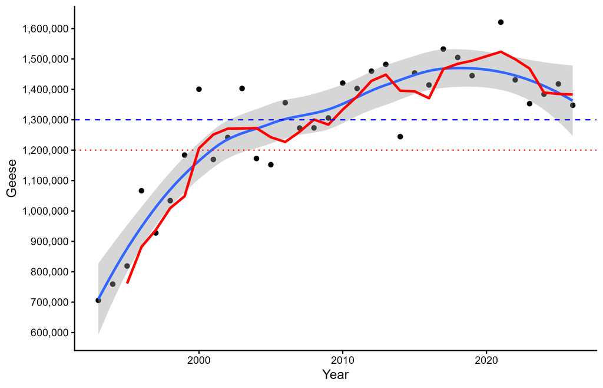

Figure 1: Temperate-breeding Canada geese abundance in spring. Circles are annual estimates of abundance. The red line is a moving 3-year average and the blue line is a smoothed (Loess model) line with 95% confidence interval (shaded area) fit to the annual estimates. The blue dashed reference line is the Mississippi Flyway Council’s population objective midpoint (1.3 million; range = 1.2 to 1.4 million). The red dashed reference line is the threshold for consideration of restrictions depending in part on the status of arctic-breeding Canada geese.

Time series statistics

| Parameter | Estimate | SE | L95%CI | U95%CI |
| --- | --- | --- | --- | --- |
| 1-year index | 1,347,724 |  |  |  |
| 3-year index<sup>a</sup> | 1,383,272 |  |  |  |
| LTA | 1,275,387 |  |  |  |
| Objective | 1,300,000 |  |  |  |
| % change from LTA | 6 |  |  |  |
| % change from obj | 6 |  |  |  |
| Mgmt index (n years) | 3 |  |  |  |

<sup>a</sup> 2024, 2025, 2026

**Harvest Strategy**  
Management index: Total temperate-breeding Canada geese in spring.

Management thresholds:  
≥1,200,000 Liberal  
Restrictive

Management prescription: Liberal.

Both temperate- and subarctic-breeding Canada geese are evaluated separately to arrive at a management decision for Canada and cackling goose seasons. The prescription above only considers the status of temperate-breeding Canada geese.

Regulatory alternatives:  
Liberal  
107 days, 5-bird bag limit, 1 September to 15 February, 4 segments.  
Standard  
107 days, 5-bird bag limit, 1 to 30 September, and 2-bird bag limit, 1 October to 15 February; or 92 days, 3-bird bag limit, 1 October to 15 February; 4 segments.  
Restrictive  
75 days, 5-bird bag limit, 1 to 15 September, and 2-bird bag limit, 1 October to 31 January; or 92 days, 2-bird bag limit, 1 September to 31 January; 3 segments.

The regulatory alternative is determined based on the estimated abundance of temperate- and subarctic-breeding Canada geese. The lower abundance threshold for temperate-breeding Canada geese is 1.2 million birds (population objective range is 1.2 to 1.4 million birds); the lower threshold for subarctic-breeding Canada geese is >15% average annual decline over 3 years (running mean), >10% average annual decline over 6 years (running mean), or >5% average annual decline over 9 years (running mean). A liberal alternative is prescribed if both (a) temperate-breeding Canada geese abundance is above 1.2 million and (b) subarctic-breeding Canada geese abundance trends do not meet or exceed lower threshold decline criteria. A standard alternative is recommended if temperate-breeding Canada geese abundance is above 1.2 million birds and subarctic-nesting Canada geese abundance trends meet or exceed lower threshold decline criteria. A restrictive alternative is recommended when both temperate- and subarctic-breeding Canada geese abundance equals or is below lower thresholds defined above.

### Data Table 2: Cackling Goose, MP

Original data source: Lincoln (harvest/harvest rate) estimates of adult abundance in summer; USFWS Headquarters. Data maintained by USFWS Headquarters.

Provided in the table below are adult abundance (Estimate) and standard error (SE) of Midcontinent Population cackling geese in summer. Also provided are the abundance moving 3-year average (M3yr) and standard error (M3yr.SE).

Table 2. Cackling goose adult abundance in summer, 1976-2024.

| Year | Estimate | SE | M3yr | M3yr.SE |
| --- | --- | --- | --- | --- |
| 1976 | 689,937 | 140,364 | NA | NA |
| 1977 | 725,005 | 228,351 | NA | NA |
| 1978 | 1,206,796 | 459,882 | 873,912 | 178,434 |
| 1979 | 1,050,747 | 255,393 | 994,182 | 190,185 |
| 1980 | NA | NA | 1,128,771 | 262,584 |
| 1981 | NA | NA | 1,050,747 | 255,043 |
| 1982 | NA | NA | NA | NA |
| 1983 | NA | NA | NA | NA |
| 1984 | NA | NA | NA | NA |
| 1985 | NA | NA | NA | NA |
| 1986 | NA | NA | NA | NA |
| 1987 | 712,977 | 362,344 | 712,977 | 369,089 |
| 1988 | 1,250,448 | 454,809 | 981,712 | 290,821 |
| 1989 | 1,573,174 | 658,658 | 1,178,866 | 291,250 |
| 1990 | 1,400,607 | 323,751 | 1,408,076 | 284,517 |
| 1991 | 2,778,372 | 1,016,952 | 1,917,385 | 417,954 |
| 1992 | 1,791,693 | 476,932 | 1,990,224 | 393,827 |
| 1993 | 860,289 | 283,821 | 1,810,118 | 391,681 |
| 1994 | 1,896,280 | 544,487 | 1,516,087 | 264,546 |
| 1995 | 1,276,821 | 446,298 | 1,344,463 | 254,637 |
| 1996 | NA | NA | 1,586,550 | 352,308 |
| 1997 | 3,448,814 | 1,195,264 | 2,362,817 | 644,433 |
| 1998 | 3,049,008 | 1,179,535 | 3,248,911 | 857,463 |
| 1999 | 2,045,882 | 518,126 | 2,847,901 | 599,210 |
| 2000 | 2,840,378 | 1,026,545 | 2,645,089 | 557,245 |
| 2001 | 1,953,276 | 560,786 | 2,279,846 | 425,300 |
| 2002 | 2,650,037 | 446,570 | 2,481,231 | 415,093 |
| 2003 | 1,628,211 | 262,940 | 2,077,175 | 256,067 |
| 2004 | 1,690,659 | 382,955 | 1,989,636 | 217,159 |
| 2005 | 2,087,970 | 409,659 | 1,802,280 | 206,246 |
| 2006 | 2,012,922 | 375,494 | 1,930,517 | 222,416 |
| 2007 | 2,144,216 | 329,163 | 2,081,703 | 215,487 |
| 2008 | 1,987,074 | 363,653 | 2,048,071 | 207,619 |
| 2009 | 3,044,642 | 613,323 | 2,391,977 | 261,375 |
| 2010 | 3,843,447 | 753,385 | 2,958,388 | 343,816 |
| 2011 | 2,541,828 | 427,092 | 3,143,306 | 352,119 |
| 2012 | 2,938,652 | 499,365 | 3,107,976 | 330,632 |
| 2013 | 3,859,084 | 694,442 | 3,113,188 | 318,554 |
| 2014 | 3,049,241 | 484,749 | 3,282,326 | 325,569 |
| 2015 | 1,783,325 | 288,378 | 2,897,217 | 295,871 |
| 2016 | 2,938,637 | 504,558 | 2,590,401 | 252,883 |
| 2017 | 2,588,622 | 413,497 | 2,436,861 | 239,920 |
| 2018 | 2,589,477 | 381,740 | 2,705,579 | 252,418 |
| 2019 | 2,010,197 | 318,993 | 2,396,099 | 214,697 |
| 2020 | NA | NA | 2,299,837 | 245,930 |
| 2021 | NA | NA | 2,010,197 | 316,095 |
| 2022 | 1,591,267 | 200,041 | 1,591,267 | 197,415 |
| 2023 | 1,836,497 | 240,707 | 1,713,882 | 153,932 |
| 2024 | 1,893,716 | 286,786 | 1,773,827 | 140,551 |

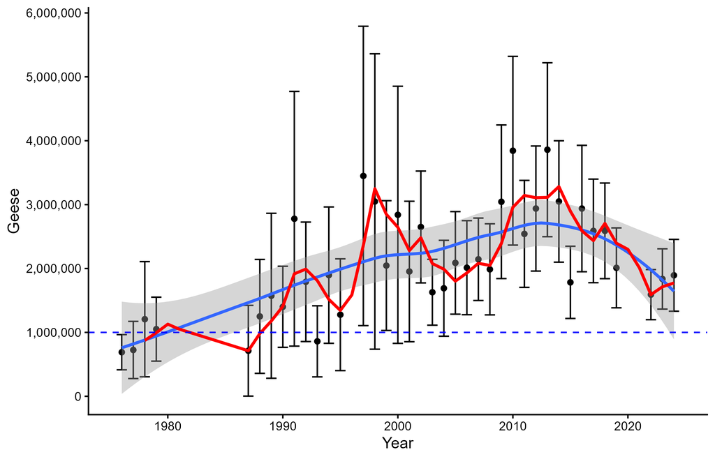

Figure 2: Cackling goose adult abundance in summer. Circles are annual estimates of abundance with 95% confidence intervals. The red line is a moving 3-year average and the blue line is a smoothed (Loess model) line with 95% confidence interval (shaded area) fit to the annual estimates. The blue dashed reference line is the Mississippi Flyway Council’s minimum population objective.

Time series statistics

| Parameter | Estimate | SE | L95%CI | U95%CI |
| --- | --- | --- | --- | --- |
| 1-year index | 1,893,716 | 286,786 | 1,331,616 | 2,455,816 |
| 3-year index<sup>a</sup> | 1,773,827 | 140,551 | 1,498,347 | 2,049,307 |
| LTA | 2,088,592 |  |  |  |
| Objective | 1,000,000 |  |  |  |
| % change from LTA | -9 |  |  |  |
| % change from obj | 77 |  |  |  |
| Mgmt index (n years) | 3 |  |  |  |

<sup>a</sup> 2022, 2023, 2024

**Harvest Strategy**  
Management index: Adult cackling geese in summer.

Management thresholds:  
≥1,000,000 Standard  
Restrict

Management prescription: Standard.

Regulatory alternatives:  
Standard  
Restrictive  
Regulations fixed until changed.

### Data Table 3: White-fronted Goose, MP

Original data source: Lincoln (harvest/harvest rate) estimates of adult abundance in summer and adult harvest rate; USFWS Headquarters. Data maintained by USFWS Headquarters.

Provided in the table below are adult abundance (N) and standard error (N.SE) of Midcontinent Population white-fronted geese in summer and harvest rate (h) and standard error (h.SE). Also provided are the moving 3-year average abundance (N.M3yr) and harvest rate (h.M3yr) and associated standard errors (N.M3yr.SE and h.M3yr.SE).

Table 3. Midcontinent Population white-fronted goose adult abundance in summer and harvest rate, 1976-2025. Note that moving 3-year averages are calculated as the most recent three years regardless of missing data so long as there are at least 2 years of data.

| Year | N | N.SE | N.M3yr | N.M3yr.SE | hrate | hrate.SE | h.M3yr | h.M3yr.SE |
| --- | --- | --- | --- | --- | --- | --- | --- | --- |
| 1976 | 548,392 | 82,909 | NA | NA | 0.076 | 0.009 | NA | NA |
| 1977 | 663,673 | 112,369 | NA | NA | 0.084 | 0.009 | NA | NA |
| 1978 | 609,879 | 96,700 | 607,315 | 56,798 | 0.088 | 0.010 | 0.083 | 0.005 |
| 1979 | 649,406 | 102,968 | 640,986 | 59,458 | 0.081 | 0.009 | 0.084 | 0.005 |
| 1980 | NA | NA | 629,643 | 70,230 | 0.073 | 0.009 | 0.081 | 0.005 |
| 1981 | NA | NA | 649,406 | 102,827 | 0.063 | 0.008 | 0.072 | 0.005 |
| 1982 | NA | NA | NA | NA | NA | NA | NA | NA |
| 1983 | NA | NA | NA | NA | NA | NA | NA | NA |
| 1984 | NA | NA | NA | NA | NA | NA | NA | NA |
| 1985 | NA | NA | NA | NA | NA | NA | NA | NA |
| 1986 | 824,882 | 377,741 | 824,882 | 384,772 | 0.050 | 0.008 | 0.058 | 0.005 |
| 1987 | 978,743 | 259,163 | 901,813 | 230,688 | 0.054 | 0.008 | 0.055 | 0.005 |
| 1988 | 1,338,163 | 365,765 | 1,047,263 | 195,838 | 0.057 | 0.007 | 0.054 | 0.004 |
| 1989 | 1,577,792 | 461,455 | 1,298,233 | 213,493 | 0.061 | 0.008 | 0.057 | 0.004 |
| 1990 | 3,207,371 | 838,970 | 2,041,109 | 341,383 | 0.053 | 0.006 | 0.057 | 0.004 |
| 1991 | 2,118,453 | 701,896 | 2,301,206 | 401,116 | 0.050 | 0.007 | 0.055 | 0.004 |
| 1992 | 939,262 | 171,931 | 2,088,362 | 376,508 | 0.065 | 0.008 | 0.056 | 0.004 |
| 1993 | 1,363,733 | 406,475 | 1,473,816 | 282,122 | 0.060 | 0.008 | 0.058 | 0.004 |
| 1994 | 1,710,598 | 379,757 | 1,337,864 | 195,129 | 0.058 | 0.007 | 0.061 | 0.004 |
| 1995 | 1,473,763 | 294,378 | 1,516,031 | 210,982 | 0.055 | 0.006 | 0.058 | 0.004 |
| 1996 | 1,926,808 | 393,427 | 1,703,723 | 210,970 | 0.060 | 0.006 | 0.058 | 0.004 |
| 1997 | 1,710,929 | 249,022 | 1,703,833 | 187,989 | 0.060 | 0.005 | 0.058 | 0.003 |
| 1998 | 2,122,517 | 359,872 | 1,920,085 | 199,369 | 0.056 | 0.005 | 0.059 | 0.003 |
| 1999 | 1,477,936 | 180,223 | 1,770,461 | 157,708 | 0.068 | 0.005 | 0.061 | 0.003 |
| 2000 | 2,630,828 | 342,496 | 2,077,094 | 175,544 | 0.059 | 0.004 | 0.061 | 0.003 |
| 2001 | 1,963,053 | 265,776 | 2,023,939 | 157,584 | 0.061 | 0.004 | 0.063 | 0.003 |
| 2002 | 2,448,836 | 389,128 | 2,347,572 | 196,494 | 0.053 | 0.004 | 0.058 | 0.002 |
| 2003 | 1,209,580 | 153,165 | 1,873,823 | 165,770 | 0.063 | 0.004 | 0.059 | 0.002 |
| 2004 | 1,510,728 | 192,304 | 1,723,048 | 151,738 | 0.063 | 0.004 | 0.060 | 0.002 |
| 2005 | 1,934,259 | 272,627 | 1,551,522 | 122,736 | 0.054 | 0.004 | 0.060 | 0.002 |
| 2006 | 2,581,737 | 369,630 | 2,008,908 | 167,664 | 0.048 | 0.003 | 0.055 | 0.002 |
| 2007 | 3,194,390 | 415,236 | 2,570,129 | 206,482 | 0.049 | 0.003 | 0.050 | 0.002 |
| 2008 | 3,400,841 | 451,102 | 3,058,989 | 237,469 | 0.046 | 0.003 | 0.048 | 0.002 |
| 2009 | 3,404,006 | 481,983 | 3,333,079 | 259,386 | 0.032 | 0.002 | 0.042 | 0.002 |
| 2010 | 2,970,195 | 389,285 | 3,258,347 | 254,226 | 0.039 | 0.003 | 0.039 | 0.002 |
| 2011 | 3,019,709 | 364,450 | 3,131,304 | 240,245 | 0.034 | 0.002 | 0.035 | 0.001 |
| 2012 | 2,820,347 | 324,571 | 2,936,751 | 207,083 | 0.037 | 0.002 | 0.037 | 0.001 |
| 2013 | 3,743,552 | 476,482 | 3,194,536 | 228,052 | 0.038 | 0.002 | 0.036 | 0.001 |
| 2014 | 3,944,541 | 555,694 | 3,502,813 | 268,870 | 0.036 | 0.002 | 0.037 | 0.001 |
| 2015 | 2,449,755 | 370,276 | 3,379,283 | 276,105 | 0.037 | 0.002 | 0.037 | 0.001 |
| 2016 | 3,254,721 | 421,598 | 3,216,339 | 263,395 | 0.042 | 0.002 | 0.038 | 0.001 |
| 2017 | 2,560,086 | 330,948 | 2,754,854 | 215,793 | 0.050 | 0.003 | 0.043 | 0.001 |
| 2018 | 3,027,396 | 399,088 | 2,947,401 | 219,052 | 0.038 | 0.002 | 0.043 | 0.001 |
| 2019 | 2,483,919 | 398,984 | 2,690,467 | 215,026 | 0.040 | 0.002 | 0.043 | 0.001 |
| 2020 | NA | NA | 2,755,657 | 277,342 | 0.037 | 0.003 | 0.038 | 0.001 |
| 2021 | 3,400,574 | 557,457 | 2,942,246 | 341,408 | 0.044 | 0.003 | 0.040 | 0.002 |
| 2022 | 1,356,346 | 178,898 | 2,378,460 | 290,873 | 0.055 | 0.003 | 0.045 | 0.002 |
| 2023 | 2,925,375 | 354,194 | 2,560,765 | 225,467 | 0.044 | 0.003 | 0.048 | 0.002 |
| 2024 | 3,068,244 | 445,630 | 2,449,988 | 199,338 | 0.055 | 0.004 | 0.051 | 0.002 |
| 2025 | NA | NA | NA | NA | 0.056 | 0.005 | 0.052 | 0.002 |

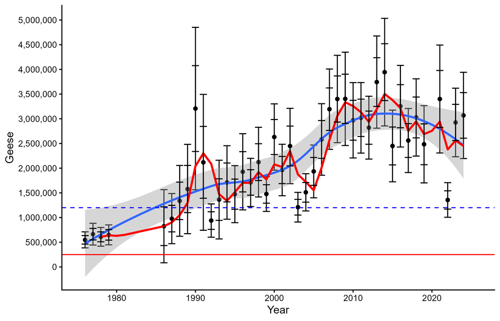

Figure 3: Midcontinent Population white-fronted goose adult abundance in summer. Circles are annual estimates of abundance with 95% and 70% confidence intervals. The red line is a moving 3-year average and the blue line is a smoothed (Loess model) line with 95% confidence interval (shaded area) fit to the annual estimates. The blue dashed reference line is the Councils’ minimum population objective, and restriction threshold if abundance is below 1.2 million geese AND adult harvest rate is above 0.075. The red reference line is the closure threshold.

Time series statistics for abundace

| Parameter | Estimate | SE | L95%CI | U95%CI |
| --- | --- | --- | --- | --- |
| 1-year index | 3,068,244 | 445,630 | 2,194,809 | 3,941,679 |
| 3-year index<sup>a</sup> | 2,449,988 | 199,338 | 2,059,286 | 2,840,691 |
| LTA | 2,133,587 |  |  |  |
| Objective | 1,200,000 |  |  |  |
| % change from LTA | 44 |  |  |  |
| % change from obj | 104 |  |  |  |
| Mgmt index (n years) | 3 |  |  |  |

<sup>a</sup> 2022, 2023, 2024

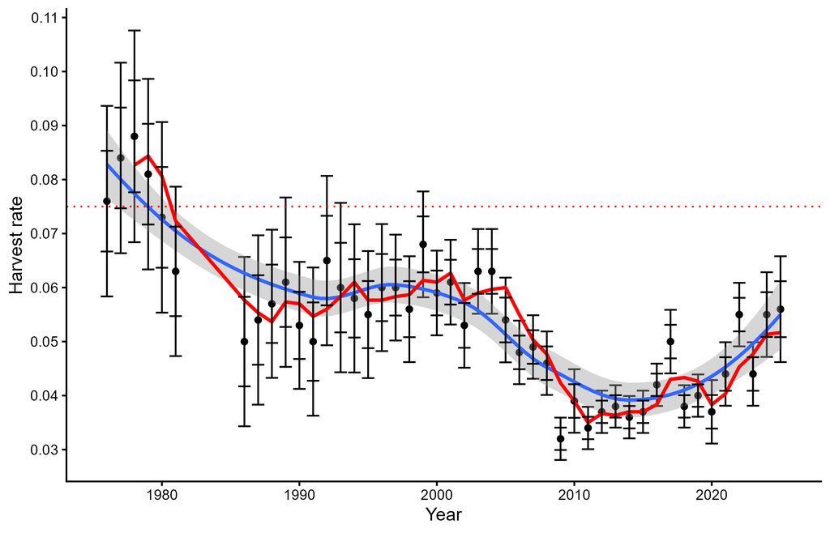

Figure 4: Midcontinent Population white-fronted goose adult harvest rate. Circles are annual estimates of harvest rate with 95% and 70% confidence intervals. The red line is a moving 3-year average and the blue line is a smoothed (Loess model) line with 95% confidence intervals (shaded area) fit to the annual estimates. The red dashed reference line is the restriction threshold if abundance is below 1.2 million geese (minumum population objective) AND adult harvest rate is above 0.075.

Time series statistics for harvest rate

| Parameter | Estimate | SE | L95%CI | U95%CI |
| --- | --- | --- | --- | --- |
| 1-year index | 0.056 | 0.005 | 0.046 | 0.066 |
| 3-year index<sup>a</sup> | 0.052 | 0.002 | 0.047 | 0.056 |
| LTA | 0.054 |  |  |  |
| Objective |  |  |  |  |
| % change from LTA | 3.875 |  |  |  |
| % change from obj |  |  |  |  |
| Mgmt index (n years) | 3.000 |  |  |  |

<sup>a</sup> 2023, 2024, 2025

**Harvest Strategy**  
Management index: Adult white-fronted geese in summer and harvest rate.

Management thresholds:  
N≥1,200,000 or h≤7.5 Standard  
N<1,200,000 and h>7.5 Restrictive  
N<250,000 Closed

Management prescription: Standard.

Regulatory alternatives:  
Low harvest States:  
Standard  
107 days and 5-bird bag in the aggregate with other dark geese, Sep 1-Feb 15  
Restrictive  
Same as Standard

Balance of States:  
Standard  
107 days and 1-goose bag, 88 days and 2-geese bag, or 74 days and 3-geese bag, Sep 1-Feb 15  
Restrictive  
88 days and 1-goose bag, or 74 days and 2-geese bag, Sep 1-Feb 15

Note: Low-harvest State status applies if the most recent 5-year average harvest for the state is <1,000 white-fronted geese annually. The aggregate bag limit of dark geese for low harvest states is only an option when the Canada and cackling goose season regulatory alternative in the Mississippi Flyway is liberal, otherwise all states in the Mississippi Flyway are subject to the alternative regulations for the Balance of States.

Decision framework: The management decision is based on two state variables; abundance and harvest rate. The probability distribution of the most recent 3-year averages relative to threshold values is used in a decision-analysis framework for setting harvest regulations. Eighty five percent of the distribution (confidence in the parameter estimate) must be below or above critical thresholds to prescribe a specific regulatory alternative. The 85% distribution corresponds to a confidence interval (CI) of 70% for the parameter estimate. Thus, if the upper or lower 70% CI for the parameter falls below or above the critical threshold value, then >85% of the distribution is below or above the threshold. The season is closed when >85% of the distribution for the most recent 3-year average population size is below 250,000 geese. A restrictive regulatory alternative is prescribed when >85% of the distribution for the most recent 3-year average population size is below 1,200,000 geese AND >85% of the distribution for the most recent 3-year average harvest rate is above 7.5%. A standard regulatory alternative is prescribed when conditions are not meet for either the restrictive or closed season regulatory alternatives.

### Data Table 4: Snow Goose, MP

Original data source: Lincoln (harvest/harvest rate) estimates of adult abundance in summer; USFWS Headquarters. Data maintained by USFWS Headquarters.

Provided in the table below are adult abundance (Estimate) and standard error (SE) of Midontinent Population lesser snow geese in summer. Also provided are the abundance moving 3-year average (M3yr) and standard error (M3yr.SE).

Table 4. Lesser snow goose abundance in summer, 1976-2024.

| Year | Estimate | SE | M3yr | M3yr.SE |
| --- | --- | --- | --- | --- |
| 1976 | 2,229,446 | 445,974 | NA | NA |
| 1977 | 2,291,969 | 329,110 | NA | NA |
| 1978 | 2,945,383 | 419,075 | 2,488,933 | 233,310 |
| 1979 | 2,262,878 | 369,416 | 2,500,076 | 214,034 |
| 1980 | NA | NA | 2,604,130 | 278,008 |
| 1981 | NA | NA | 2,262,878 | 368,910 |
| 1982 | NA | NA | NA | NA |
| 1983 | NA | NA | NA | NA |
| 1984 | NA | NA | NA | NA |
| 1985 | NA | NA | NA | NA |
| 1986 | NA | NA | NA | NA |
| 1987 | NA | NA | NA | NA |
| 1988 | 2,377,544 | 633,351 | 2,377,544 | 645,140 |
| 1989 | 4,726,867 | 1,442,374 | 3,552,206 | 784,549 |
| 1990 | 2,792,014 | 772,618 | 3,298,808 | 580,826 |
| 1991 | 6,703,631 | 3,489,578 | 4,740,837 | 1,291,659 |
| 1992 | 6,763,659 | 1,961,696 | 5,419,768 | 1,362,023 |
| 1993 | 3,857,223 | 965,950 | 5,774,838 | 1,380,115 |
| 1994 | 9,430,642 | 2,432,328 | 6,683,841 | 1,095,547 |
| 1995 | 7,482,881 | 1,660,258 | 6,923,582 | 1,043,376 |
| 1996 | 6,650,151 | 1,989,181 | 7,854,558 | 1,191,364 |
| 1997 | 11,234,261 | 2,835,597 | 8,455,764 | 1,292,050 |
| 1998 | 6,663,391 | 858,898 | 8,182,601 | 1,207,638 |
| 1999 | 11,162,736 | 1,337,866 | 9,686,796 | 1,099,463 |
| 2000 | 13,660,059 | 1,304,607 | 10,495,396 | 695,403 |
| 2001 | 13,870,173 | 1,446,373 | 12,897,656 | 791,320 |
| 2002 | 12,922,382 | 1,397,263 | 13,484,205 | 800,058 |
| 2003 | 9,181,559 | 1,014,456 | 11,991,371 | 755,758 |
| 2004 | 12,314,316 | 1,285,417 | 11,472,752 | 726,237 |
| 2005 | 12,067,721 | 1,295,264 | 11,187,866 | 696,067 |
| 2006 | 11,608,259 | 1,230,754 | 11,996,765 | 725,270 |
| 2007 | 15,613,032 | 1,545,562 | 13,096,337 | 789,488 |
| 2008 | 16,844,789 | 1,876,030 | 14,688,693 | 917,265 |
| 2009 | 15,941,470 | 2,155,179 | 16,133,097 | 1,083,184 |
| 2010 | 11,303,712 | 1,147,008 | 14,696,657 | 1,023,163 |
| 2011 | 19,331,481 | 2,061,827 | 15,525,554 | 1,065,843 |
| 2012 | 15,182,500 | 1,542,921 | 15,272,564 | 938,518 |
| 2013 | 16,716,301 | 1,698,333 | 17,076,761 | 1,030,204 |
| 2014 | 22,545,855 | 2,285,131 | 18,148,219 | 1,073,779 |
| 2015 | 10,772,049 | 1,068,792 | 16,678,068 | 1,010,746 |
| 2016 | 16,862,142 | 1,578,138 | 16,726,682 | 994,936 |
| 2017 | 13,328,154 | 1,316,932 | 13,654,115 | 779,467 |
| 2018 | 9,823,750 | 1,108,330 | 13,338,016 | 780,376 |
| 2019 | 7,969,277 | 750,075 | 10,373,727 | 624,454 |
| 2020 | NA | NA | 8,896,514 | 661,798 |
| 2021 | NA | NA | 7,969,277 | 743,261 |
| 2022 | 4,963,581 | 509,119 | 4,963,581 | 502,435 |
| 2023 | 8,420,540 | 759,333 | 6,692,061 | 450,128 |
| 2024 | 7,178,726 | 774,980 | 6,854,282 | 396,688 |

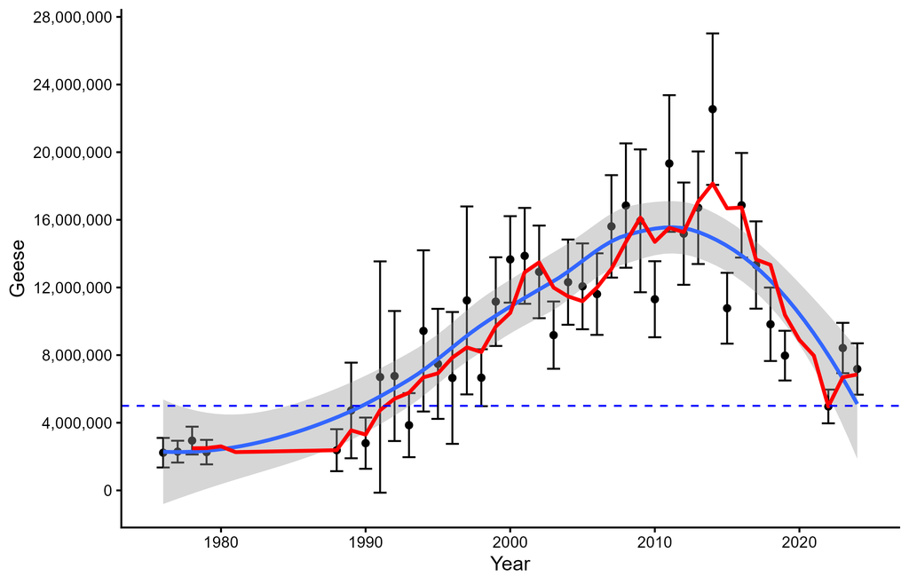

Figure 5: Lesser snow goose abundance in summer. Circles are annual estimates of abundance with 95% confidence intervals. The red line is a moving 3-year average and the blue line is a smoothed (Loess model) line with 95% confidence interval (shaded area) fit to the annual estimates. The blue dashed reference line is the Councils’ minimum population objective.

Time series statistics

| Parameter | Estimate | SE | L95%CI | U95%CI |
| --- | --- | --- | --- | --- |
| 1-year index | 7,178,726 | 774,980 | 5,659,764 | 8,697,687 |
| 3-year index<sup>a</sup> | 6,854,282 | 396,688 | 6,076,773 | 7,631,791 |
| LTA | 10,021,521 |  |  |  |
| Objective | 5,000,000 |  |  |  |
| % change from LTA | -28 |  |  |  |
| % change from obj | 37 |  |  |  |
| Mgmt index (n years) | 3 |  |  |  |

<sup>a</sup> 2022, 2023, 2024

**Harvest Strategy**  
Management index: Adult lesser snow geese in summer

Management thresholds:  
≥5,000,000 Standard  
Restrictive

Management prescription: Standard.

Regulatory alternatives:  
Standard  
Restrictive  
Regulations fixed until changed.

### Data Table 5: Ross’s Goose

Original data source: Lincoln (harvest/harvest rate) estimates of adult abundance in summer; USFWS Headquarters. Data maintained by USFWS Headquarters.

Provided in the table below are adult abundance (Estimate) and standard error (SE) of Ross’s geese in summer. Also provided are the abundance moving 3-year average (M3yr) and standard error (M3yr.SE).

Table 5. Ross's goose adult abundance in summer, 1989-2024.

| Year | Estimate | SE | M3yr | M3yr.SE |
| --- | --- | --- | --- | --- |
| 1989 | 116,866 | 71,045 | 116,866 | 71,923 |
| 1990 | 258,492 | 157,995 | 187,679 | 86,293 |
| 1991 | 168,034 | 102,061 | 181,131 | 66,984 |
| 1992 | 83,320 | 50,424 | 169,949 | 64,331 |
| 1993 | NA | NA | 125,677 | 56,872 |
| 1994 | 94,495 | 37,188 | 88,908 | 31,657 |
| 1995 | 434,328 | 263,963 | 264,412 | 132,596 |
| 1996 | NA | NA | 264,412 | 132,596 |
| 1997 | 375,367 | 95,064 | 404,848 | 139,154 |
| 1998 | 702,478 | 141,465 | 538,923 | 85,082 |
| 1999 | 669,387 | 130,240 | 582,411 | 71,399 |
| 2000 | 1,150,308 | 241,587 | 840,724 | 104,282 |
| 2001 | 1,480,683 | 365,152 | 1,100,126 | 153,035 |
| 2002 | 1,551,512 | 248,810 | 1,394,168 | 170,037 |
| 2003 | 909,787 | 155,679 | 1,313,994 | 156,994 |
| 2004 | 1,327,719 | 197,082 | 1,263,006 | 118,680 |
| 2005 | 1,077,835 | 141,826 | 1,105,114 | 98,043 |
| 2006 | 1,205,217 | 140,028 | 1,203,590 | 95,387 |
| 2007 | 2,294,146 | 305,862 | 1,525,733 | 122,216 |
| 2008 | 2,819,327 | 376,741 | 2,106,230 | 168,437 |
| 2009 | 1,897,032 | 312,017 | 2,336,835 | 192,648 |
| 2010 | 3,151,489 | 436,369 | 2,622,616 | 219,826 |
| 2011 | 2,769,111 | 367,864 | 2,605,877 | 219,859 |
| 2012 | 3,197,823 | 438,758 | 3,039,474 | 240,358 |
| 2013 | 3,863,577 | 504,961 | 3,276,837 | 251,492 |
| 2014 | 6,165,750 | 856,593 | 4,409,050 | 363,519 |
| 2015 | 2,036,736 | 237,162 | 4,022,021 | 342,732 |
| 2016 | 3,324,330 | 368,058 | 3,842,272 | 320,248 |
| 2017 | 2,858,910 | 414,999 | 2,739,992 | 199,983 |
| 2018 | 3,161,910 | 576,628 | 3,115,050 | 266,465 |
| 2019 | 2,744,717 | 360,455 | 2,921,846 | 264,730 |
| 2020 | NA | NA | 2,953,314 | 342,333 |
| 2021 | NA | NA | 2,744,717 | 360,280 |
| 2022 | 1,138,224 | 174,201 | 1,138,224 | 172,823 |
| 2023 | 3,594,202 | 488,960 | 2,366,213 | 259,344 |
| 2024 | 1,394,040 | 177,372 | 2,042,155 | 183,318 |

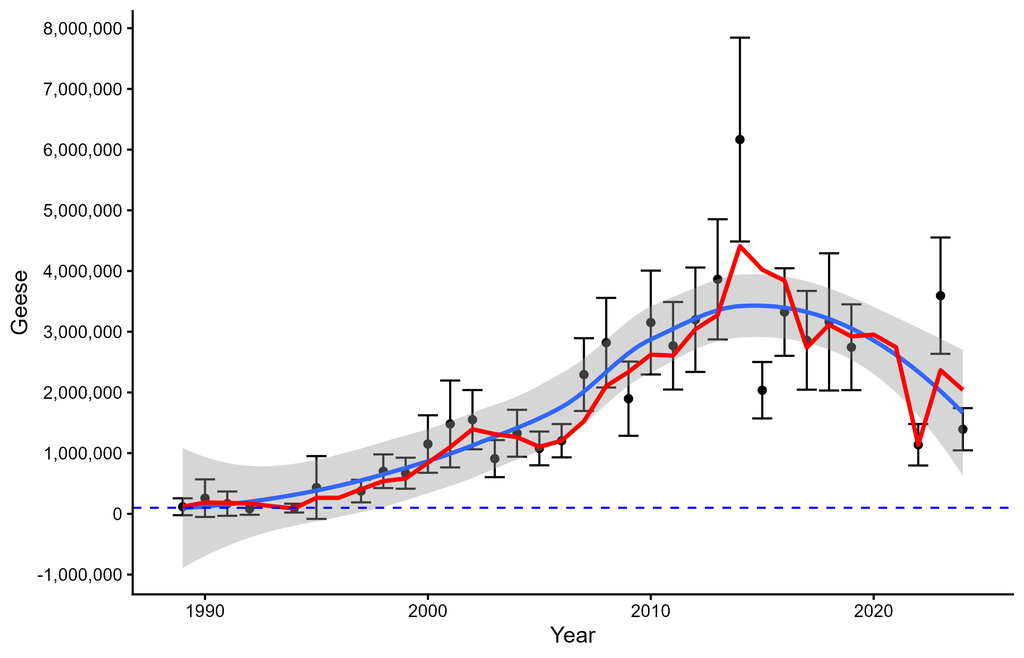

Figure 6: Ross’s goose adult abundance in summer. Circles are annual estimates of abundance with 95% confidence intervals. The red line is a moving 3-year average and the blue line is a smoothed (Loess model) line with 95% confidence interval (shaded area) fit to the annual estimates. The blue dashed reference line is the Councils’ minimum population objective.

Time series statistics

[output not shown]

<sup>a</sup> 2022, 2023, 2024

**Harvest Strategy**  
Management index: Adult Ross’s geese in summer.

Management thresholds:  
≥100,000 Standard  
Restrictive

Management prescription: Standard.

Regulatory alternatives:  
Standard  
Restrictive  
Regulations fixed until changed.

### Data Table 6: Tundra Swan, EP

Original data source: Cooperative State-Federal Midwinter Waterfowl Survey in the U.S. Mississippi Flyway; U.S. Atlantic Flyway; and Ontario, Canada. Data maintained by USFWS Atlantic Flyway Office.

Provided in the table below are abundance of Eastern population tundra swans in winter by area including the U.S. Mississippi Flyway (MF), U.S. Atlantic Flyway (AF), Ontario (ON), and in total (Total). Also provided is the total abundance moving 3-year average (M3yr). So long as there are counts in the U.S. Mississippi and Atlantic flyways and Ontario, the total winter count is interpreted as the minimum known population size with no variance.

Table 6. Eastern Population tundra swan abundance in winter, 1982-2026.

| Year | AF | MF | ON | Total | M3yr |
| --- | --- | --- | --- | --- | --- |
| 1982 | 72,907 | 275 | 0 | 73,182 | NA |
| 1983 | 86,464 | 550 | 500 | 87,514 | NA |
| 1984 | 81,235 | 25 | 100 | 81,360 | 80,685 |
| 1985 | 93,909 | 525 | 2,500 | 96,934 | 88,603 |
| 1986 | 90,766 | 150 | 25 | 90,941 | 89,745 |
| 1987 | 94,504 | 250 | 1,000 | 95,754 | 94,543 |
| 1988 | 77,110 | 375 | 1,200 | 78,685 | 88,460 |
| 1989 | 91,150 | 125 | 25 | 91,300 | 88,580 |
| 1990 | 90,593 | 17 | 9 | 90,619 | 86,868 |
| 1991 | 97,424 | 20 | 754 | 98,198 | 93,372 |
| 1992 | 109,788 | 327 | 2,929 | 113,044 | 100,620 |
| 1993 | 76,593 | 858 | 739 | 78,190 | 96,477 |
| 1994 | 84,527 | 61 | 184 | 84,772 | 92,002 |
| 1995 | 80,222 | 2,447 | 2,473 | 85,142 | 82,701 |
| 1996 | 79,021 | 393 | 113 | 79,527 | 83,147 |
| 1997 | 86,120 | 233 | 6,027 | 92,380 | 85,683 |
| 1998 | 96,544 | 1,335 | 2,679 | 100,558 | 90,822 |
| 1999 | 109,041 | 1,618 | 296 | 110,955 | 101,298 |
| 2000 | 103,082 | 3,364 | 8,897 | 115,343 | 108,952 |
| 2001 | 98,143 | 46 | 231 | 98,420 | 108,239 |
| 2002 | 103,827 | 3,661 | 7,169 | 114,657 | 109,473 |
| 2003 | 108,187 | 2,160 | 1,379 | 111,726 | 108,268 |
| 2004 | 94,975 | 2,094 | 13,737 | 110,806 | 112,396 |
| 2005 | 68,735 | 1,054 | 2,668 | 72,457 | 98,330 |
| 2006 | 70,452 | 1,069 | 9,746 | 81,267 | 88,177 |
| 2007 | 87,840 | 10,521 | 16,057 | 114,418 | 89,381 |
| 2008 | 88,502 | 1,826 | 5,917 | 96,245 | 97,310 |
| 2009 | 99,304 | 552 | 336 | 100,192 | 103,618 |
| 2010 | 91,909 | 1,302 | 4,081 | 97,292 | 97,910 |
| 2011 | 93,767 | 2,427 | 1,445 | 97,639 | 98,374 |
| 2012 | 86,793 | 12,436 | 13,512 | 112,741 | 102,557 |
| 2013 | 98,493 | 1,035 | 7,527 | 107,055 | 105,812 |
| 2014 | 103,844 | 848 | 287 | 104,979 | 108,258 |
| 2015 | 107,936 | 2,964 | 6,196 | 117,096 | 109,710 |
| 2016 | 86,619 | 12,982 | 13,992 | 113,593 | 111,889 |
| 2017 | 115,425 | 1,909 | 1,953 | 119,287 | 116,659 |
| 2018 | 111,077 | 431 | 61 | 111,569 | 114,816 |
| 2019 | 72,365 | 733 | 19,721 | 92,819 | 107,892 |
| 2020 | 61,354 | 9,241 | 7,991 | 78,586 | 94,325 |
| 2021 | 76,701 | 1,677 | 8,302 | 86,680 | 86,028 |
| 2022 | 89,142 | 1,717 | 4,871 | 95,730 | 86,999 |
| 2023 | 113,420 | 4,806 | 19,555 | 137,781 | 106,730 |
| 2024 | 48,678 | 6,986 | 8,773 | 64,437 | 99,316 |
| 2025 | 66,510 | 1,451 | 8,067 | 76,028 | 92,749 |
| 2026 | 92,069 | 238 | 2,786 | 95,093 | 78,519 |

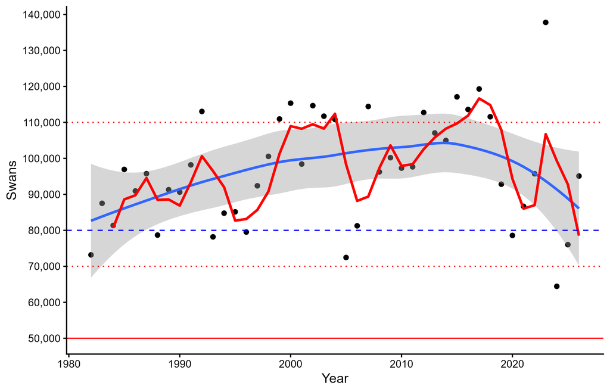

Time series statistics

| Parameter | Estimate | SE | L95%CI | U95%CI |
| --- | --- | --- | --- | --- |
| 1-year index | 95,093 |  |  |  |
| 3-year index<sup>a</sup> | 78,519 |  |  |  |
| LTA | 96,770 |  |  |  |
| Objective | 80,000 |  |  |  |
| % change from LTA | -2 |  |  |  |
| % change from obj | -2 |  |  |  |
| Mgmt index (n years) | 3 |  |  |  |

<sup>a</sup> 2024, 2025, 2026

**Harvest Strategy**  
Management index: Total tundra swans in winter.

Management thresholds:  
>110,000 Liberal  
>70,000 Moderate  
≥50,000 Restrictive  
Closed

Management prescription: Moderate.

Regulatory alternatives:  
Liberal  
Moderate  
Restrictive  
Closed  
Regulations fixed until changed.

The permit allocation in the Atlantic Flyway and Central Flyway combined will be: Restrictive, 7,200; Moderate, 9,600; and Liberal, 12,000 permits.

The regulatory alternative for total permits for the Atlantic and Central Flyways combined is prescribed based on the estimated winter population size from monitoring data. The analytical framework derives a recent 3-year average population size estimate and is compared to threshold values in a decision-analysis framework for prescribing the appropriate regulatory alternative. The recent 3-year average population size estimate must exceed the threshold value to change regulations, either more restrictive or liberal. The season is closed when the recent 3-year average winter population estimate is ≤50,000 swans and will remain closed until the estimate is ≥70,000 swans. A restrictive alternative is prescribed when the estimate is >50,000 and ≤70,000 swans and will remain restrictive until the estimate is ≥80,000 swans. A moderate alternative is prescribed when the estimate is >70,000 and ≤110,000 swans. A liberal alternative is prescribed when the estimate is >110,000 swans. Allocation of permits among States must be approved by the Atlantic and Central Flyway Councils and consistent with the Councils’ management plan for this population.

### Data Table 7: Sandhill Crane, EP

Original data source: Mississippi and Atlantic Flyways Cooperative State Surveys. Data maintained by States in the Mississippi and Atlantic Flyways and USFWS Headquarters.

Provided in the table below are abundance (Total) of Eastern Population sandhill cranes in fall. Also provided is the total abundance moving 3-year average (M3yr).

Table 7. Eastern Population sandhill crane abundance (index) in fall, 1979-2024.

| Year | Total | M3yr |
| --- | --- | --- |
| 1979 | 14,385 | NA |
| 1980 | 15,808 | NA |
| 1981 | 11,943 | 14,045 |
| 1982 | 13,879 | 13,877 |
| 1983 | 16,148 | 13,990 |
| 1984 | 16,363 | 15,463 |
| 1985 | 16,170 | 16,227 |
| 1986 | 17,043 | 16,525 |
| 1987 | 22,342 | 18,518 |
| 1988 | 26,086 | 21,824 |
| 1989 | 22,785 | 23,738 |
| 1990 | 23,792 | 24,221 |
| 1991 | 24,685 | 23,754 |
| 1992 | 26,656 | 25,044 |
| 1993 | 26,187 | 25,843 |
| 1994 | 26,783 | 26,542 |
| 1995 | 33,774 | 28,915 |
| 1996 | 29,753 | 30,103 |
| 1997 | 27,641 | 30,389 |
| 1998 | 37,827 | 31,740 |
| 1999 | 33,583 | 33,017 |
| 2000 | 33,105 | 34,838 |
| 2001 | NA | NA |
| 2002 | 31,575 | 32,754 |
| 2003 | 29,300 | 31,327 |
| 2004 | 28,822 | 29,899 |
| 2005 | 37,708 | 31,943 |
| 2006 | 37,529 | 34,686 |
| 2007 | 37,943 | 37,727 |
| 2008 | 44,110 | 39,861 |
| 2009 | 60,028 | 47,360 |
| 2010 | 49,647 | 51,262 |
| 2011 | 76,028 | 61,901 |
| 2012 | 86,989 | 70,888 |
| 2013 | 64,213 | 75,743 |
| 2014 | 82,694 | 77,965 |
| 2015 | 94,676 | 80,528 |
| 2016 | 70,858 | 82,743 |
| 2017 | 69,989 | 78,508 |
| 2018 | 97,073 | 79,307 |
| 2019 | 89,504 | 85,522 |
| 2020 | 94,961 | 93,846 |
| 2021 | 90,029 | 91,498 |
| 2022 | 107,164 | 97,385 |
| 2023 | 110,646 | 102,613 |
| 2024 | 91,485 | 103,098 |

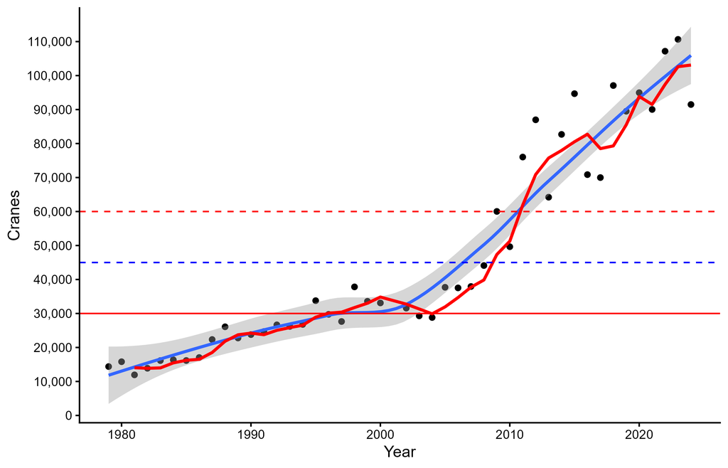

Figure 8: Eastern Population sandhill crane abundance (index) in fall. Circles are annual estimates of abundance. The red line is a moving 3-year average and the blue line is a smoothed (Loess model) line with 95% confidence interval (shaded area) fit to the annual estimates. The blue dashed reference line is the Mississippi Flyway Council’s population objective midpoint (range = 30,000-60,000 cranes). Red dashed reference lines represent threshold values in the harvest strategy decision and the red reference line is the closure threshold.

Time series statistics

| Parameter | Estimate | SE | L95%CI | U95%CI |
| --- | --- | --- | --- | --- |
| 1-year index | 91,485 |  |  |  |
| 3-year index<sup>a</sup> | 103,098 |  |  |  |
| LTA | 45,641 |  |  |  |
| Objective | 45,000 |  |  |  |
| % change from LTA | 100 |  |  |  |
| % change from obj | 129 |  |  |  |
| Mgmt index (n years) | 3 |  |  |  |

<sup>a</sup> 2022, 2023, 2024

**Harvest Strategy**  
Management index: Total sandhill cranes in fall.

Management thresholds:  
≥60,000 Standard  
≥30,000 Restrictive  
Closed

Management prescription: Standard.

Regulatory alternatives:  
Standard  
Total permits for the Atlantic and Mississippi Flyways combined is 12% of estimated fall population size.  
Restrictive  
Total permits for the Atlantic and Mississippi Flyways combined is 10% of estimated fall population size.  
Closed

A standard alternative is prescribed when the fall abundance index is ≥60,000 cranes. A restrictive alternative is prescribed when the fall abundance index is ≥30,000 and <60,000 cranes. The season is closed when the fall abundance index is <30,000 cranes.

### Data Table 8: Sandhill Crane, MP

Original data source: Photo-corrected annual spring survey along the Platte River of Nebraska; USFWS Headquarters. Data maintained by USFWS Headquarters.

Provided in the table below are abundance (Estimate) and standard error (SE) of Midcontinent Population sandhill cranes in spring. Also provided are the abundance moving 3-year average (M3yr) and standard error (M3yr.SE).

Table 8. U.S. Midcontinent Population sandhill crane abundance in spring, 1982-2026.

| Year | Estimate | SE | M3yr | M3yr.SE |
| --- | --- | --- | --- | --- |
| 1982 | 417,263 | 42,331 | NA | NA |
| 1983 | 343,378 | 31,674 | NA | NA |
| 1984 | 261,802 | 24,198 | 340,814 | 33,569 |
| 1985 | 514,763 | 49,650 | 373,314 | 36,760 |
| 1986 | 353,040 | 37,340 | 376,535 | 38,492 |
| 1987 | 416,058 | 65,588 | 427,954 | 52,157 |
| 1988 | 463,457 | 53,213 | 410,852 | 53,316 |
| 1989 | 391,995 | 51,349 | 423,837 | 57,068 |
| 1990 | 412,154 | 50,496 | 422,535 | 51,698 |
| 1991 | 340,645 | 33,897 | 381,598 | 45,955 |
| 1992 | 406,457 | 50,644 | 386,419 | 45,693 |
| 1993 | 378,883 | 50,454 | 375,328 | 45,678 |
| 1994 | 477,215 | 50,910 | 420,852 | 50,670 |
| 1995 | 326,181 | 35,256 | 394,093 | 46,117 |
| 1996 | 519,984 | 62,582 | 441,127 | 50,831 |
| 1997 | 534,630 | 86,889 | 460,265 | 65,088 |
| 1998 | 530,848 | 79,164 | 528,487 | 76,883 |
| 1999 | 284,858 | 35,599 | 450,112 | 70,908 |
| 2000 | 490,118 | 71,754 | 435,275 | 65,020 |
| 2001 | 413,498 | 64,221 | 396,158 | 59,274 |
| 2002 | 315,044 | 42,218 | 406,220 | 60,705 |
| 2003 | 348,023 | 41,263 | 358,855 | 50,363 |
| 2004 | 426,534 | 43,337 | 363,200 | 42,281 |
| 2005 | 491,915 | 47,392 | 422,157 | 44,071 |
| 2006 | 216,810 | 18,054 | 378,420 | 38,514 |
| 2007 | 384,118 | 39,637 | 364,281 | 37,162 |
| 2008 | 545,884 | 76,107 | 382,271 | 50,627 |
| 2009 | 565,257 | 50,923 | 498,420 | 57,609 |
| 2010 | 691,534 | 85,236 | 600,892 | 72,228 |
| 2011 | 482,797 | 44,851 | 579,863 | 62,902 |
| 2012 | 339,642 | 31,609 | 504,658 | 58,526 |
| 2013 | 867,061 | 126,196 | 563,167 | 79,448 |
| 2014 | 617,903 | 60,551 | 608,202 | 82,847 |
| 2015 | 386,471 | 49,504 | 623,812 | 85,718 |
| 2016 | 405,716 | 44,935 | 470,030 | 52,078 |
| 2017 | 568,369 | 72,987 | 453,519 | 57,146 |
| 2018 | 1,005,612 | 105,654 | 659,899 | 78,547 |
| 2019 | 945,996 | 133,127 | 839,992 | 106,791 |
| 2020 | NA | NA | NA | NA |
| 2021 | 782,462 | 309,357 | 911,357 | 203,787 |
| 2022 | 685,476 | 85,473 | 804,645 | 200,608 |
| 2023 | 1,259,199 | 159,840 | 909,046 | 207,007 |
| 2024 | 420,840 | 66,572 | 788,505 | 111,484 |
| 2025 | 1,005,573 | 148,568 | 895,204 | 131,723 |
| 2026 | 527,440 | 55,561 | 651,284 | 99,317 |

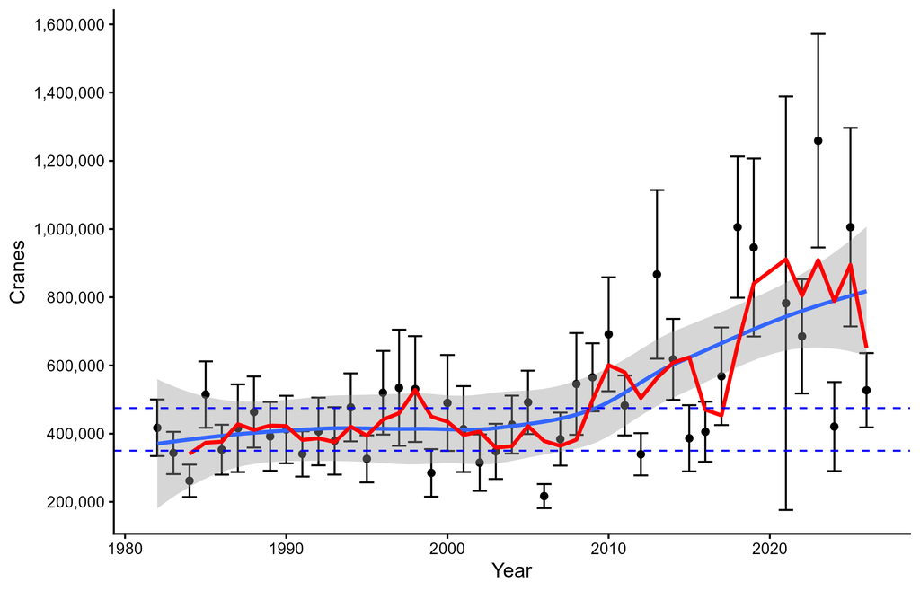

Figure 9: Midcontinent Population sandhill crane abundance in spring. Circles are annual estimates of abundance with 95% confidence intervals. The red line is a moving 3-year average and the blue line is a smoothed (Loess model) line with 95% confidence interval (shaded area) fit to the annual estimates. The blue dashed reference lines represent the Councils’ population objective range.

Time series statistics

| Parameter | Estimate | SE | L95%CI | U95%CI |
| --- | --- | --- | --- | --- |
| 1-year index | 527,440 | 55,561 | 418,540 | 636,340 |
| 3-year index<sup>a</sup> | 651,284 | 99,317 | 456,624 | 845,945 |
| LTA | 512,453 |  |  |  |
| Objective | 412,500 |  |  |  |
| % change from LTA | 3 |  |  |  |
| % change from obj | 58 |  |  |  |
| Mgmt index (n years) | 3 |  |  |  |

<sup>a</sup> 2024, 2025, 2026

**Harvest Strategy**  
Management index: Sandhill cranes in spring.

Management thresholds: N/A.

Management prescription: N/A.

Regulatory alternatives:  
Regulations fixed until changed.

### Data Table 9a: Mourning Dove, EMU (summer)

Original data source: State and Federal mourning dove banding programs; State-Federal cooperative Harvest Information Program and Parts Collection Survey; and USGS NA Breeding Bird Survey (BBS). Data maintained by each cooperator and the USFWS Headquarters.

Provided in the table below are estimated abundance (Estimate) and lower and upper 95% credible intervals (L95%CI, U95%CI) of Eastern Management Unit Population mourning doves in summer. Also provided is the abundance moving 3-year average (M3yr). Estimates of abundance are based on an integrated population model combining banding, harvest, and BBS data.

Table 9a. Eastern Management Unit Population mourning dove abundance in summer, 2007-2025.

| Year | Estimate | L95%CI | U95%CI | M3yr |
| --- | --- | --- | --- | --- |
| 2007 | 97,260,389 | 77,958,848 | 120,396,478 | NA |
| 2008 | 93,686,839 | 75,003,919 | 116,348,748 | NA |
| 2009 | 95,449,665 | 76,293,138 | 118,467,203 | 95,465,631 |
| 2010 | 90,512,023 | 72,626,118 | 112,226,512 | 93,216,176 |
| 2011 | 95,154,086 | 76,162,807 | 118,184,910 | 93,705,258 |
| 2012 | 93,360,347 | 74,772,289 | 115,708,726 | 93,008,819 |
| 2013 | 94,230,293 | 75,431,201 | 116,722,853 | 94,248,242 |
| 2014 | 86,723,270 | 69,624,955 | 107,774,678 | 91,437,970 |
| 2015 | 86,508,089 | 69,362,931 | 107,346,536 | 89,153,884 |
| 2016 | 83,756,577 | 67,321,959 | 103,936,874 | 85,662,645 |
| 2017 | 87,563,389 | 69,798,980 | 108,751,553 | 85,942,685 |
| 2018 | 80,882,387 | 64,938,694 | 100,969,513 | 84,067,451 |
| 2019 | 84,340,038 | 67,244,888 | 104,718,533 | 84,261,938 |
| 2020 | 83,981,652 | 67,324,909 | 104,285,642 | 83,068,025 |
| 2021 | 79,384,211 | 63,584,534 | 98,561,541 | 82,568,633 |
| 2022 | 84,019,035 | 67,392,180 | 104,139,462 | 82,461,633 |
| 2023 | 82,859,191 | 66,488,241 | 102,814,785 | 82,087,479 |
| 2024 | 82,544,529 | 65,939,827 | 102,384,702 | 83,140,918 |
| 2025 | 82,499,589 | 66,192,890 | 102,516,240 | 82,634,437 |

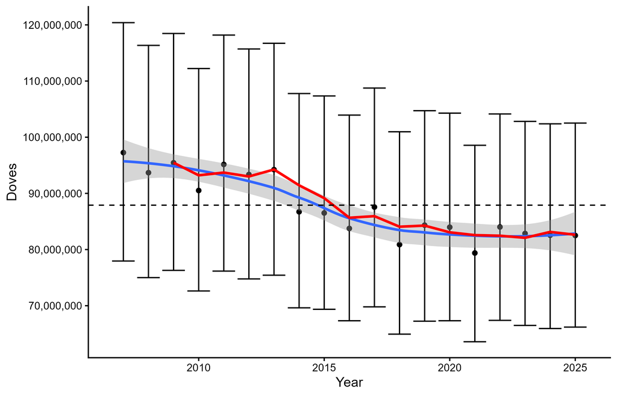

Figure 10: Eastern Management Unit Population mourning dove abundance in summer. Black circles are annual estimates of abundance with 95% confidence intervals. The red line is a moving 3-year average and the blue line is a smoothed (Loess model) line with 95% confidence interval (shaded area) fit to the annual estimates. The black dashed reference line is the long-term average.

Time series statistics

| Parameter | Abundance | SE | L95%CI | U95%CI |
| --- | --- | --- | --- | --- |
| 1-year index | 82,499,589 |  | 66,192,890 | 102,516,240 |
| 3-year index<sup>a</sup> | 82,634,437 |  |  |  |
| LTA | 88,194,816 |  |  |  |
| Objective |  |  |  |  |
| % change from LTA | -6 |  |  |  |
| % change from obj |  |  |  |  |
| Mgmt index (n years) | 3 |  |  |  |

<sup>a</sup> 2023, 2024, 2025

**Harvest Strategy**  
Management index: Mourning doves in summer.

Management thresholds:  
Standard  
Restrictive  
Closed  
See the national mourning dove harvest strategy assessment memo for the derived threshold values based on the decision framework for mourning doves in the Eastern Management Unit.

Management prescription: See the national mourning dove harvest strategy assessment memo for the decision based on the adaptive harvest management decision framework for the Eastern Management Unit.

Regulatory alternatives:  
Standard  
90 days, 15 dove bag limit, Sep 1–Jan 15  
Restrictive  
70 days, 10 dove bag limit, Sep 1–Jan 15  
Closed

### Data Table 9b: Mourning Dove, CMU (summer)

Original data source: State and Federal mourning dove banding programs; State-Federal cooperative Harvest Information Program and Parts Collection Survey; and USGS NA Breeding Bird Survey (BBS). Data maintained by each cooperator and the USFWS Headquarters.

Provided in the table below are estimated abundance (Estimate) and lower and upper 95% credible intervals (L95%CI, U95%CI) of Central Management Unit Population mourning doves in summer. Also provided is the abundance moving 3-year average (M3yr). Estimates of abundance are based on an integrated population model combining banding, harvest, and BBS data.

Table 9b. Central Management Unit Population mourning dove abundance in summer, 2007-2025.

| Year | Estimate | L95%CI | U95%CI | M3yr |
| --- | --- | --- | --- | --- |
| 2007 | 197,361,897 | 160,247,384 | 238,479,322 | NA |
| 2008 | 188,658,833 | 152,321,538 | 228,837,056 | NA |
| 2009 | 190,326,084 | 153,983,304 | 231,268,400 | 192,115,605 |
| 2010 | 180,364,347 | 145,850,231 | 219,031,836 | 186,449,755 |
| 2011 | 171,291,166 | 138,571,031 | 207,944,475 | 180,660,533 |
| 2012 | 180,004,219 | 145,403,034 | 218,054,350 | 177,219,911 |
| 2013 | 191,635,893 | 154,904,828 | 232,645,662 | 180,977,093 |
| 2014 | 200,334,716 | 161,825,408 | 243,588,508 | 190,658,276 |
| 2015 | 202,189,729 | 163,486,692 | 245,483,473 | 198,053,446 |
| 2016 | 189,665,636 | 153,380,171 | 230,366,422 | 197,396,694 |
| 2017 | 189,165,821 | 152,718,344 | 229,360,026 | 193,673,729 |
| 2018 | 172,609,328 | 139,589,037 | 209,273,909 | 183,813,595 |
| 2019 | 171,234,851 | 138,544,005 | 207,455,633 | 177,670,000 |
| 2020 | 163,059,682 | 131,626,182 | 198,392,468 | 168,967,954 |
| 2021 | 157,174,380 | 126,991,939 | 190,972,074 | 163,822,971 |
| 2022 | 178,345,326 | 144,409,969 | 216,194,015 | 166,193,130 |
| 2023 | 188,722,758 | 151,848,795 | 229,304,789 | 174,747,488 |
| 2024 | 201,682,621 | 163,017,657 | 244,312,236 | 189,583,568 |
| 2025 | 200,485,969 | 161,446,802 | 244,250,274 | 196,963,783 |

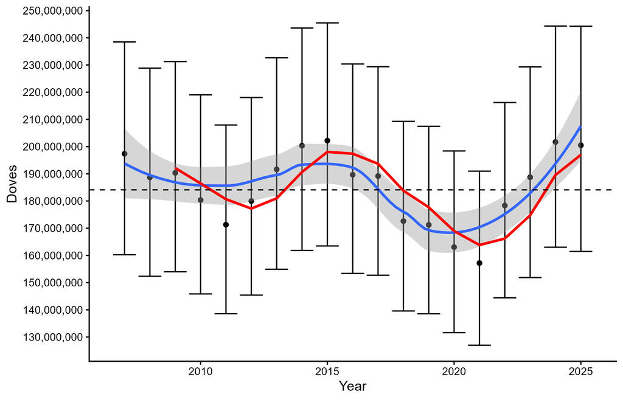

Figure 11: Central Management Unit Population mourning dove abundance in summer. Black circles are annual estimates of abundance with 95% confidence intervals. The red line is a moving 3-year average and the blue line is a smoothed (Loess model) line with 95% confidence interval (shaded area) fit to the annual estimates. The black dashed reference line is the long-term average.

Time series statistics

| Parameter | Abundance | SE | L95%CI | U95%CI |
| --- | --- | --- | --- | --- |
| 1-year index | 200,485,969 |  | 161,446,802 | 244,250,274 |
| 3-year index<sup>a</sup> | 196,963,783 |  |  |  |
| LTA | 183,759,287 |  |  |  |
| Objective |  |  |  |  |
| % change from LTA | 9 |  |  |  |
| % change from obj |  |  |  |  |
| Mgmt index (n years) | 3 |  |  |  |

<sup>a</sup> 2023, 2024, 2025

**Harvest Strategy**  
Management index: Mourning doves in summer.

Management thresholds:  
Standard  
Restrictive  
Closed  
See the national mourning dove harvest strategy assessment memo for the derived threshold values based on the decision framework for mourning doves in the Central Management Unit.

Management prescription: See the national mourning dove harvest strategy assessment memo for the decision based on the adaptive harvest management decision framework for the Central Management Unit.

Regulatory alternatives:  
Standard  
90 days, 15 dove bag limit, Sep 1–Jan 15  
Restrictive  
70 days, 10 dove bag limit, Sep 1–Jan 15  
Closed

### Data Table 10a: American Woodcock, EMR

Original data source: State and Federal cooperative American Woodcock Singing-ground Survey; States in the Eastern and Central management regions, USFWS, and Canadian Wildlife Service. Data maintained by USFWS Headquarters.

Provided in the table below are estimated abundance (Index) and lower and upper 95% credible intervals (L95%CI, U95%CI) of Eastern Management Region Population American woodcock in spring. Also provided are the abundance moving 3-year average (M3yr) and associated lower and upper 70% credible intervals (L70%CI, U70%CI). Estimates of abundance are derived using a hierarchical model.

Table 10a. Eastern Management Region Population American woodcock abundance in spring, 1968-2026.

| Year | Index | L95%CI | U95%CI | M3yr | L70%CI | U70%CI |
| --- | --- | --- | --- | --- | --- | --- |
| 1968 | 4.29 | 3.84 | 4.83 | NA | NA | NA |
| 1969 | 4.27 | 3.87 | 4.73 | NA | NA | NA |
| 1970 | 4.22 | 3.86 | 4.62 | 4.26 | 4.06 | 4.47 |
| 1971 | 4.13 | 3.80 | 4.48 | 4.21 | 4.03 | 4.39 |
| 1972 | 4.07 | 3.76 | 4.40 | 4.14 | 3.97 | 4.30 |
| 1973 | 4.01 | 3.72 | 4.32 | 4.07 | 3.92 | 4.22 |
| 1974 | 4.03 | 3.74 | 4.33 | 4.04 | 3.89 | 4.18 |
| 1975 | 3.94 | 3.66 | 4.25 | 3.99 | 3.85 | 4.13 |
| 1976 | 3.71 | 3.44 | 4.00 | 3.89 | 3.76 | 4.03 |
| 1977 | 3.60 | 3.35 | 3.89 | 3.75 | 3.62 | 3.89 |
| 1978 | 3.44 | 3.20 | 3.72 | 3.59 | 3.46 | 3.72 |
| 1979 | 3.45 | 3.21 | 3.74 | 3.50 | 3.38 | 3.63 |
| 1980 | 3.35 | 3.11 | 3.62 | 3.42 | 3.29 | 3.55 |
| 1981 | 3.29 | 3.06 | 3.55 | 3.37 | 3.25 | 3.49 |
| 1982 | 3.15 | 2.92 | 3.40 | 3.26 | 3.15 | 3.39 |
| 1983 | 3.18 | 2.96 | 3.43 | 3.21 | 3.09 | 3.32 |
| 1984 | 3.15 | 2.94 | 3.39 | 3.16 | 3.05 | 3.28 |
| 1985 | 3.18 | 2.96 | 3.43 | 3.17 | 3.07 | 3.29 |
| 1986 | 3.22 | 2.99 | 3.49 | 3.18 | 3.08 | 3.30 |
| 1987 | 3.29 | 3.05 | 3.58 | 3.23 | 3.12 | 3.36 |
| 1988 | 3.38 | 3.12 | 3.68 | 3.30 | 3.17 | 3.43 |
| 1989 | 3.41 | 3.14 | 3.76 | 3.36 | 3.23 | 3.51 |
| 1990 | 3.30 | 3.04 | 3.62 | 3.36 | 3.23 | 3.52 |
| 1991 | 3.25 | 3.00 | 3.56 | 3.32 | 3.19 | 3.47 |
| 1992 | 3.14 | 2.89 | 3.43 | 3.23 | 3.10 | 3.38 |
| 1993 | 3.14 | 2.89 | 3.43 | 3.18 | 3.05 | 3.32 |
| 1994 | 3.02 | 2.78 | 3.30 | 3.10 | 2.98 | 3.24 |
| 1995 | 2.93 | 2.69 | 3.19 | 3.03 | 2.91 | 3.16 |
| 1996 | 2.81 | 2.58 | 3.06 | 2.92 | 2.81 | 3.05 |
| 1997 | 2.87 | 2.64 | 3.12 | 2.87 | 2.76 | 2.99 |
| 1998 | 2.96 | 2.73 | 3.22 | 2.88 | 2.77 | 3.00 |
| 1999 | 3.04 | 2.81 | 3.31 | 2.96 | 2.84 | 3.08 |
| 2000 | 2.99 | 2.77 | 3.25 | 3.00 | 2.89 | 3.12 |
| 2001 | 2.94 | 2.72 | 3.20 | 2.99 | 2.88 | 3.12 |
| 2002 | 2.91 | 2.68 | 3.16 | 2.95 | 2.84 | 3.07 |
| 2003 | 2.99 | 2.76 | 3.25 | 2.95 | 2.83 | 3.07 |
| 2004 | 3.07 | 2.83 | 3.35 | 2.99 | 2.87 | 3.11 |
| 2005 | 3.10 | 2.86 | 3.38 | 3.05 | 2.94 | 3.18 |
| 2006 | 2.99 | 2.77 | 3.26 | 3.05 | 2.94 | 3.18 |
| 2007 | 2.87 | 2.66 | 3.13 | 2.99 | 2.87 | 3.11 |
| 2008 | 2.84 | 2.63 | 3.08 | 2.90 | 2.79 | 3.02 |
| 2009 | 2.87 | 2.66 | 3.13 | 2.86 | 2.75 | 2.98 |
| 2010 | 3.03 | 2.81 | 3.28 | 2.91 | 2.81 | 3.03 |
| 2011 | 3.01 | 2.79 | 3.25 | 2.97 | 2.86 | 3.09 |
| 2012 | 3.06 | 2.84 | 3.30 | 3.03 | 2.92 | 3.15 |
| 2013 | 3.04 | 2.82 | 3.29 | 3.03 | 2.92 | 3.15 |
| 2014 | 2.94 | 2.73 | 3.17 | 3.01 | 2.90 | 3.13 |
| 2015 | 2.85 | 2.64 | 3.08 | 2.94 | 2.84 | 3.05 |
| 2016 | 2.85 | 2.65 | 3.09 | 2.88 | 2.78 | 2.99 |
| 2017 | 2.69 | 2.50 | 2.92 | 2.80 | 2.70 | 2.91 |
| 2018 | 2.55 | 2.36 | 2.77 | 2.70 | 2.60 | 2.80 |
| 2019 | 2.58 | 2.40 | 2.80 | 2.61 | 2.51 | 2.71 |
| 2020 | 2.60 | 2.40 | 2.82 | 2.58 | 2.48 | 2.68 |
| 2021 | 2.65 | 2.46 | 2.86 | 2.61 | 2.52 | 2.71 |
| 2022 | 2.73 | 2.54 | 2.95 | 2.66 | 2.57 | 2.76 |
| 2023 | 2.71 | 2.52 | 2.93 | 2.70 | 2.60 | 2.80 |
| 2024 | 2.84 | 2.64 | 3.07 | 2.76 | 2.66 | 2.87 |
| 2025 | 2.80 | 2.60 | 3.03 | 2.78 | 2.68 | 2.89 |
| 2026 | 2.77 | 2.56 | 3.01 | 2.80 | 2.70 | 2.91 |

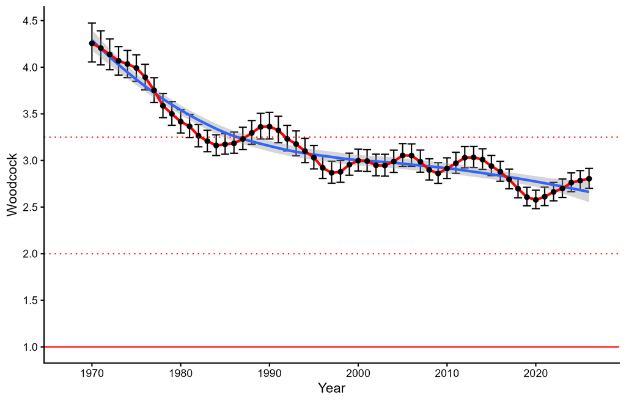

Time series statistics

| Parameter | Abundance | SE | L95%CI | U95%CI |
| --- | --- | --- | --- | --- |
| 1-year index | 2.77 |  | 2.56 | 3.01 |
| 3-year index<sup>a</sup> | 2.80 |  | 2.70 | 2.91 |
| LTA | 3.17 |  |  |  |
| Objective | 3.25 |  |  |  |
| % change from LTA | -11.59 |  |  |  |
| % change from obj | -13.71 |  |  |  |
| Mgmt index (n years) | 3.00 |  |  |  |

<sup>a</sup> 2024, 2025, 2026

**Harvest Strategy**  
Management index: Moving 3-year average index in spring.

Management thresholds:  
≥3.25 Liberal  
≥2.00 Moderate  
≥1.00 Restrictive  
Closed

Management prescription: Moderate.

Regulatory alternatives:  
Liberal  
60-day season, 3-bird bag limit, Sep 31-Jan 31  
Moderate  
45-day season, 3-bird bag limit, Sep 31-Jan 31  
Restrictive  
30-day season, 3-bird bag limit, Sep 31-Jan 31  
closed  
Any change in regulations would remain in place for three years.

Decision framework: The management decision is based on the lower 70% confidence interval (CI) of the moving 3-year mean index of singing males per route. The liberal alternative is prescribed if the lower 70% CI of the 3-year average is ≥3.25, if not, the moderate alternative is prescribed if the lower 70% CI is <3.25 to ≥2.0, if not, the restrictive alternative is prescribed if the lower 70% CI is <2.0 to ≥1.0, and if not, then the season is closed (i.e., <1.0).

### Data Table 10b: American Woodcock, CMR

Original data source: State and Federal cooperative American Woodcock Singing-ground Survey; States in the Eastern and Central management regions, USFWS, and Canadian Wildlife Service. Data maintained by USFWS Headquarters.

Provided in the table below are estimated abundance (Index) and lower and upper 95% credible intervals (L95%CI, U95%CI) of Central Management Region Population American woodcock in spring. Also provided are the abundance moving 3-year average (M3yr) and associated lower and upper 70% credible intervals (L70%CI, U70%CI). Estimates of abundance are derived using a hierarchical model.

Table 10b. Central Management Region Population American woodcock abundance in spring, 1968-2026.

| Year | Index | L95%CI | U95%CI | M3yr | L70%CI | U70%CI |
| --- | --- | --- | --- | --- | --- | --- |
| 1968 | 3.53 | 3.23 | 3.87 | NA | NA | NA |
| 1969 | 3.60 | 3.33 | 3.89 | NA | NA | NA |
| 1970 | 3.73 | 3.47 | 4.02 | 3.62 | 3.49 | 3.76 |
| 1971 | 3.70 | 3.44 | 3.97 | 3.68 | 3.55 | 3.81 |
| 1972 | 3.85 | 3.59 | 4.14 | 3.76 | 3.64 | 3.89 |
| 1973 | 4.01 | 3.73 | 4.30 | 3.85 | 3.73 | 3.98 |
| 1974 | 4.26 | 3.97 | 4.57 | 4.04 | 3.91 | 4.17 |
| 1975 | 4.26 | 3.97 | 4.56 | 4.18 | 4.05 | 4.31 |
| 1976 | 4.20 | 3.92 | 4.49 | 4.25 | 4.11 | 4.38 |
| 1977 | 4.27 | 3.99 | 4.55 | 4.24 | 4.11 | 4.37 |
| 1978 | 4.44 | 4.15 | 4.73 | 4.30 | 4.17 | 4.43 |
| 1979 | 4.42 | 4.14 | 4.71 | 4.38 | 4.25 | 4.51 |
| 1980 | 4.14 | 3.88 | 4.41 | 4.33 | 4.21 | 4.46 |
| 1981 | 3.74 | 3.52 | 3.98 | 4.10 | 3.99 | 4.22 |
| 1982 | 3.53 | 3.32 | 3.75 | 3.81 | 3.70 | 3.91 |
| 1983 | 3.39 | 3.18 | 3.61 | 3.56 | 3.46 | 3.66 |
| 1984 | 3.50 | 3.29 | 3.73 | 3.47 | 3.38 | 3.57 |
| 1985 | 3.74 | 3.51 | 4.00 | 3.55 | 3.44 | 3.65 |
| 1986 | 3.94 | 3.70 | 4.21 | 3.73 | 3.62 | 3.84 |
| 1987 | 3.93 | 3.69 | 4.21 | 3.87 | 3.76 | 3.99 |
| 1988 | 3.95 | 3.72 | 4.20 | 3.94 | 3.83 | 4.06 |
| 1989 | 3.87 | 3.63 | 4.12 | 3.92 | 3.81 | 4.03 |
| 1990 | 3.86 | 3.62 | 4.11 | 3.89 | 3.79 | 4.01 |
| 1991 | 3.85 | 3.62 | 4.10 | 3.86 | 3.75 | 3.97 |
| 1992 | 3.40 | 3.19 | 3.63 | 3.70 | 3.60 | 3.81 |
| 1993 | 3.21 | 3.01 | 3.42 | 3.49 | 3.39 | 3.59 |
| 1994 | 2.91 | 2.73 | 3.11 | 3.17 | 3.09 | 3.27 |
| 1995 | 2.93 | 2.74 | 3.12 | 3.02 | 2.93 | 3.10 |
| 1996 | 2.78 | 2.60 | 2.97 | 2.87 | 2.79 | 2.96 |
| 1997 | 2.79 | 2.60 | 2.99 | 2.83 | 2.75 | 2.92 |
| 1998 | 3.00 | 2.80 | 3.23 | 2.86 | 2.77 | 2.95 |
| 1999 | 3.00 | 2.79 | 3.22 | 2.93 | 2.84 | 3.02 |
| 2000 | 3.11 | 2.90 | 3.35 | 3.04 | 2.94 | 3.14 |
| 2001 | 2.99 | 2.79 | 3.22 | 3.03 | 2.94 | 3.14 |
| 2002 | 2.90 | 2.69 | 3.13 | 3.00 | 2.91 | 3.10 |
| 2003 | 2.93 | 2.73 | 3.15 | 2.94 | 2.85 | 3.04 |
| 2004 | 3.04 | 2.83 | 3.25 | 2.96 | 2.86 | 3.06 |
| 2005 | 3.09 | 2.89 | 3.32 | 3.02 | 2.93 | 3.12 |
| 2006 | 3.01 | 2.81 | 3.22 | 3.05 | 2.95 | 3.14 |
| 2007 | 2.97 | 2.77 | 3.19 | 3.02 | 2.93 | 3.12 |
| 2008 | 2.78 | 2.60 | 2.97 | 2.92 | 2.83 | 3.01 |
| 2009 | 2.77 | 2.59 | 2.97 | 2.84 | 2.76 | 2.93 |
| 2010 | 2.89 | 2.71 | 3.08 | 2.81 | 2.73 | 2.90 |
| 2011 | 3.06 | 2.87 | 3.26 | 2.91 | 2.82 | 2.99 |
| 2012 | 3.11 | 2.92 | 3.33 | 3.02 | 2.93 | 3.11 |
| 2013 | 3.04 | 2.85 | 3.24 | 3.07 | 2.98 | 3.16 |
| 2014 | 2.87 | 2.69 | 3.06 | 3.01 | 2.92 | 3.10 |
| 2015 | 2.96 | 2.78 | 3.16 | 2.96 | 2.87 | 3.05 |
| 2016 | 2.99 | 2.81 | 3.19 | 2.94 | 2.86 | 3.03 |
| 2017 | 2.96 | 2.78 | 3.16 | 2.97 | 2.88 | 3.06 |
| 2018 | 2.57 | 2.41 | 2.75 | 2.84 | 2.76 | 2.93 |
| 2019 | 2.53 | 2.37 | 2.70 | 2.68 | 2.61 | 2.77 |
| 2020 | 2.50 | 2.31 | 2.72 | 2.53 | 2.45 | 2.62 |
| 2021 | 2.44 | 2.28 | 2.61 | 2.49 | 2.41 | 2.57 |
| 2022 | 2.52 | 2.36 | 2.69 | 2.48 | 2.41 | 2.57 |
| 2023 | 2.63 | 2.46 | 2.81 | 2.53 | 2.45 | 2.61 |
| 2024 | 2.67 | 2.50 | 2.86 | 2.61 | 2.53 | 2.69 |
| 2025 | 2.58 | 2.41 | 2.77 | 2.63 | 2.54 | 2.71 |
| 2026 | 2.42 | 2.24 | 2.60 | 2.56 | 2.47 | 2.64 |

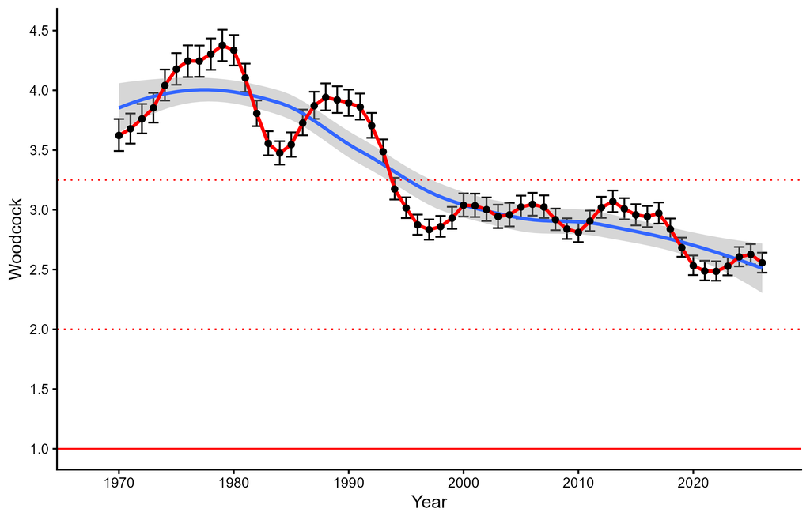

Time series statistics

| Parameter | Abundance | SE | L95%CI | U95%CI |
| --- | --- | --- | --- | --- |
| 1-year index | 2.42 |  | 2.24 | 2.60 |
| 3-year index<sup>a</sup> | 2.56 |  | 2.47 | 2.64 |
| LTA | 3.31 |  |  |  |
| Objective | 3.25 |  |  |  |
| % change from LTA | -22.82 |  |  |  |
| % change from obj | -21.33 |  |  |  |
| Mgmt index (n years) | 3.00 |  |  |  |

<sup>a</sup> 2024, 2025, 2026

**Harvest Strategy**  
Management index: Moving 3-year average index in spring.

Management thresholds:  
≥3.25 Liberal  
≥2.00 Moderate  
≥1.00 Restrictive  
Closed

Management prescription: Moderate.

Regulatory alternatives:  
Liberal  
60-day season, 3-bird bag limit, Sep 31-Jan 31  
Moderate  
45-day season, 3-bird bag limit, Sep 31-Jan 31  
Restrictive  
30-day season, 3-bird bag limit, Sep 31-Jan 31  
closed  
Any change in regulations would remain in place for three years.

Decision framework: The management decision is based on the lower 70% confidence interval (CI) of the moving 3-year mean index of singing males per route. The liberal alternative is prescribed if the lower 70% CI of the 3-year average is ≥3.25, if not, the moderate alternative is prescribed if the lower 70% CI is <3.25 to ≥2.0, if not, the restrictive alternative is prescribed if the lower 70% CI is <2.0 to ≥1.0, and if not, then the season is closed (i.e., <1.0).

### Data Table 11a: American Coot

Original data source: North American Breeding Bird Survey; U.S. Geological Survey. Data maintained by U.S. Geological Survey.

Provided in the table below are estimated abundance (Index, birds per route) and lower and upper 95% credible intervals (L95%CI, U95%CI) of American coots in spring in the United States (BBS Core area). Also provided is the abundance moving 3-year average (M3yr).

| Year | Index | L95%CI | U95%CI | M3yr |
| --- | --- | --- | --- | --- |
| 1966 | 3.55 | 1.71 | 13.51 | NA |
| 1967 | 3.05 | 1.79 | 7.10 | NA |
| 1968 | 2.28 | 1.44 | 5.26 | 2.96 |
| 1969 | 2.80 | 1.78 | 5.59 | 2.71 |
| 1970 | 2.24 | 1.45 | 4.30 | 2.44 |
| 1971 | 2.50 | 1.64 | 4.44 | 2.51 |
| 1972 | 2.65 | 1.75 | 4.60 | 2.46 |
| 1973 | 2.54 | 1.70 | 4.22 | 2.56 |
| 1974 | 2.56 | 1.69 | 4.33 | 2.58 |
| 1975 | 2.74 | 1.77 | 4.78 | 2.61 |
| 1976 | 2.65 | 1.76 | 4.44 | 2.65 |
| 1977 | 2.32 | 1.61 | 3.88 | 2.57 |
| 1978 | 3.23 | 2.17 | 5.20 | 2.73 |
| 1979 | 3.75 | 2.51 | 6.21 | 3.10 |
| 1980 | 2.52 | 1.82 | 3.71 | 3.17 |
| 1981 | 2.38 | 1.71 | 3.56 | 2.88 |
| 1982 | 3.05 | 2.17 | 4.61 | 2.65 |
| 1983 | 3.24 | 2.32 | 4.82 | 2.89 |
| 1984 | 3.71 | 2.53 | 5.87 | 3.33 |
| 1985 | 3.59 | 2.44 | 5.86 | 3.51 |
| 1986 | 3.07 | 2.07 | 5.12 | 3.46 |
| 1987 | 2.90 | 2.01 | 4.68 | 3.19 |
| 1988 | 2.04 | 1.44 | 3.23 | 2.67 |
| 1989 | 1.60 | 1.18 | 2.42 | 2.18 |
| 1990 | 1.36 | 0.99 | 2.19 | 1.67 |
| 1991 | 1.35 | 0.96 | 2.23 | 1.44 |
| 1992 | 1.36 | 1.00 | 1.99 | 1.36 |
| 1993 | 2.35 | 1.58 | 4.10 | 1.69 |
| 1994 | 3.58 | 2.38 | 5.75 | 2.43 |
| 1995 | 4.87 | 3.23 | 7.80 | 3.60 |
| 1996 | 5.73 | 3.81 | 9.16 | 4.73 |
| 1997 | 5.89 | 3.88 | 9.17 | 5.50 |
| 1998 | 5.52 | 3.68 | 8.61 | 5.71 |
| 1999 | 5.15 | 3.43 | 8.14 | 5.52 |
| 2000 | 3.59 | 2.45 | 5.51 | 4.75 |
| 2001 | 2.78 | 1.93 | 4.19 | 3.84 |
| 2002 | 2.05 | 1.42 | 3.08 | 2.81 |
| 2003 | 1.39 | 1.01 | 1.95 | 2.07 |
| 2004 | 1.36 | 0.98 | 1.98 | 1.60 |
| 2005 | 1.23 | 0.90 | 1.85 | 1.33 |
| 2006 | 1.33 | 0.94 | 2.19 | 1.31 |
| 2007 | 2.20 | 1.50 | 3.50 | 1.59 |
| 2008 | 2.05 | 1.41 | 3.25 | 1.86 |
| 2009 | 2.79 | 1.87 | 4.32 | 2.35 |
| 2010 | 3.17 | 2.11 | 4.95 | 2.67 |
| 2011 | 2.94 | 1.96 | 4.58 | 2.97 |
| 2012 | 2.25 | 1.55 | 3.43 | 2.79 |
| 2013 | 2.74 | 1.81 | 4.39 | 2.65 |
| 2014 | 2.16 | 1.46 | 3.33 | 2.38 |
| 2015 | 1.76 | 1.25 | 2.58 | 2.22 |
| 2016 | 1.22 | 0.89 | 1.73 | 1.71 |
| 2017 | 1.20 | 0.87 | 1.68 | 1.39 |
| 2018 | 1.53 | 1.10 | 2.22 | 1.31 |
| 2019 | 1.83 | 1.27 | 2.82 | 1.52 |
| 2020 | 1.52 | 0.93 | 2.98 | 1.63 |
| 2021 | 1.24 | 0.86 | 1.90 | 1.53 |
| 2022 | 1.55 | 1.03 | 2.49 | 1.44 |
| 2023 | 1.44 | 0.98 | 2.26 | 1.41 |
| 2024 | 1.29 | 0.89 | 1.97 | 1.43 |
| 2025 | 1.00 | 0.69 | 1.55 | 1.24 |

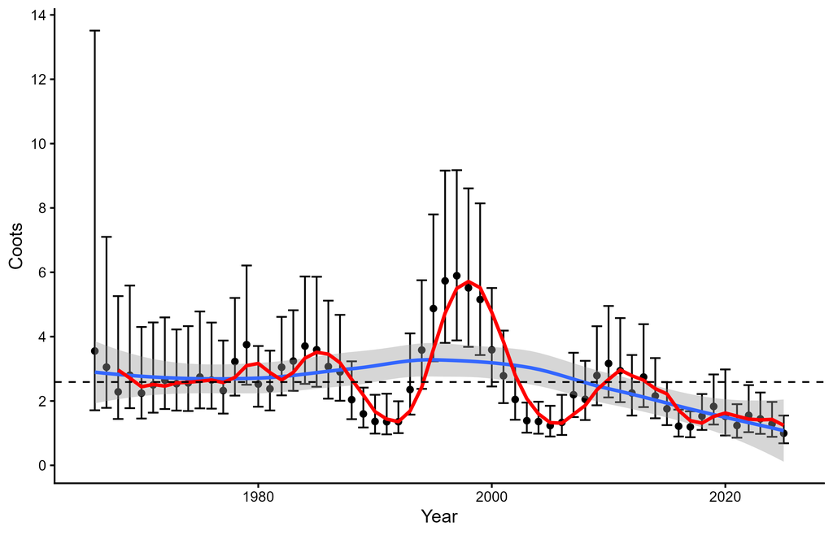

Figure 14: American coot abundance (index) in the United States in spring. Circles are annual estimates of abundance with 95% confidence intervals. The red line is a moving 3-year average and the blue line is a smoothed (Loess model) line with 95% confidence interval (shaded area) fit to the annual estimates. The black dashed reference line is the long term average.

Time series statistics

| Parameter | Estimate | SE | L95%CI | U95%CI |
| --- | --- | --- | --- | --- |
| 1-year index | 1.00 |  | 0.69 | 1.55 |
| 3-year index<sup>a</sup> | 1.24 |  |  |  |
| LTA | 2.59 |  |  |  |
| Objective |  |  |  |  |
| % change from LTA | -61.53 |  |  |  |
| % change from obj |  |  |  |  |
| Mgmt index (n years) | 1.00 |  |  |  |

<sup>a</sup> 2023, 2024, 2025

**Harvest Strategy**  
Management index: Ameican coots per route in spring.

Management thresholds: N/A.

Management prescription: N/A.

Regulatory alternatives:  
Fixed until changed.

### Data Table 11b: Wilson’s Snipe

Original data source: North American Breeding Bird Survey; U.S. Geological Survey. Data maintained by U.S. Geological Survey.

Provided in the table below are estimated abundance (Index, birds per route) and lower and upper 95% credible intervals (L95%CI, U95%CI) of Wilson’s snipe in spring in the United States (BBS Core area). Also provided is the abundance moving 3-year average (M3yr).

| Year | Index | L95%CI | U95%CI | M3yr |
| --- | --- | --- | --- | --- |
| 1966 | 1.58 | 1.27 | 1.98 | NA |
| 1967 | 1.56 | 1.27 | 1.93 | NA |
| 1968 | 1.57 | 1.30 | 1.90 | 1.57 |
| 1969 | 1.62 | 1.35 | 1.93 | 1.58 |
| 1970 | 1.69 | 1.43 | 1.99 | 1.63 |
| 1971 | 1.73 | 1.47 | 2.03 | 1.68 |
| 1972 | 1.69 | 1.44 | 1.97 | 1.70 |
| 1973 | 1.78 | 1.54 | 2.07 | 1.73 |
| 1974 | 1.94 | 1.68 | 2.24 | 1.80 |
| 1975 | 2.17 | 1.87 | 2.51 | 1.96 |
| 1976 | 1.92 | 1.66 | 2.20 | 2.01 |
| 1977 | 1.86 | 1.62 | 2.14 | 1.98 |
| 1978 | 1.96 | 1.72 | 2.24 | 1.91 |
| 1979 | 2.07 | 1.82 | 2.37 | 1.96 |
| 1980 | 2.03 | 1.78 | 2.33 | 2.02 |
| 1981 | 2.16 | 1.89 | 2.48 | 2.09 |
| 1982 | 2.28 | 2.01 | 2.62 | 2.16 |
| 1983 | 2.36 | 2.08 | 2.69 | 2.27 |
| 1984 | 2.44 | 2.15 | 2.76 | 2.36 |
| 1985 | 2.35 | 2.07 | 2.66 | 2.38 |
| 1986 | 2.19 | 1.94 | 2.47 | 2.33 |
| 1987 | 2.10 | 1.86 | 2.36 | 2.21 |
| 1988 | 2.00 | 1.78 | 2.25 | 2.10 |
| 1989 | 2.02 | 1.80 | 2.27 | 2.04 |
| 1990 | 1.91 | 1.70 | 2.16 | 1.98 |
| 1991 | 1.86 | 1.65 | 2.10 | 1.93 |
| 1992 | 1.82 | 1.62 | 2.04 | 1.86 |
| 1993 | 1.90 | 1.70 | 2.13 | 1.86 |
| 1994 | 1.92 | 1.72 | 2.17 | 1.88 |
| 1995 | 1.97 | 1.76 | 2.21 | 1.93 |
| 1996 | 2.02 | 1.81 | 2.27 | 1.97 |
| 1997 | 2.18 | 1.95 | 2.46 | 2.06 |
| 1998 | 2.25 | 2.02 | 2.53 | 2.15 |
| 1999 | 2.37 | 2.11 | 2.67 | 2.27 |
| 2000 | 2.27 | 2.02 | 2.55 | 2.30 |
| 2001 | 2.26 | 2.01 | 2.55 | 2.30 |
| 2002 | 2.20 | 1.96 | 2.49 | 2.24 |
| 2003 | 2.10 | 1.87 | 2.37 | 2.19 |
| 2004 | 2.10 | 1.87 | 2.38 | 2.13 |
| 2005 | 2.05 | 1.83 | 2.31 | 2.09 |
| 2006 | 1.89 | 1.69 | 2.12 | 2.01 |
| 2007 | 1.98 | 1.77 | 2.24 | 1.97 |
| 2008 | 1.96 | 1.75 | 2.20 | 1.94 |
| 2009 | 1.92 | 1.71 | 2.17 | 1.95 |
| 2010 | 2.17 | 1.92 | 2.48 | 2.02 |
| 2011 | 2.20 | 1.92 | 2.55 | 2.10 |
| 2012 | 1.91 | 1.68 | 2.20 | 2.09 |
| 2013 | 2.14 | 1.86 | 2.50 | 2.09 |
| 2014 | 2.20 | 1.90 | 2.58 | 2.09 |
| 2015 | 2.03 | 1.78 | 2.35 | 2.13 |
| 2016 | 1.88 | 1.65 | 2.17 | 2.04 |
| 2017 | 1.82 | 1.61 | 2.08 | 1.91 |
| 2018 | 1.94 | 1.72 | 2.21 | 1.88 |
| 2019 | 2.16 | 1.89 | 2.49 | 1.97 |
| 2020 | 1.89 | 1.62 | 2.27 | 2.00 |
| 2021 | 1.65 | 1.46 | 1.89 | 1.90 |
| 2022 | 1.89 | 1.65 | 2.19 | 1.81 |
| 2023 | 1.71 | 1.50 | 1.96 | 1.75 |
| 2024 | 1.71 | 1.50 | 1.96 | 1.77 |
| 2025 | 1.55 | 1.35 | 1.78 | 1.66 |

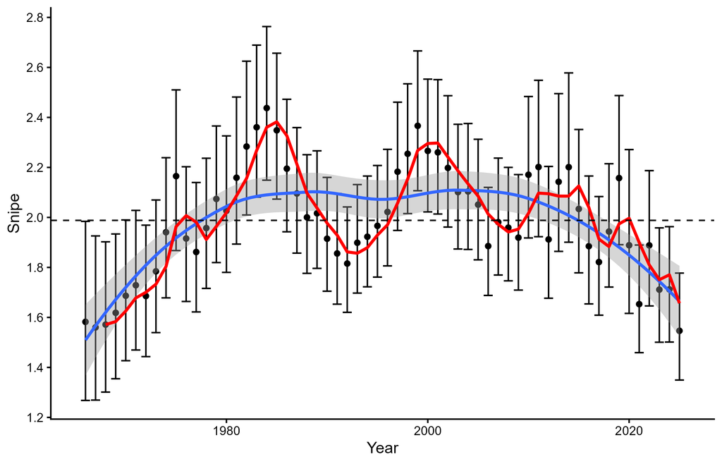

Figure 15: Wilson’s snipe abundance (index) in the United States in spring. Circles are annual estimates of abundance with 95% confidence intervals. The red line is a moving 3-year average and the blue line is a smoothed (Loess model) line with 95% confidence interval (shaded area) fit to the annual estimates. The black dashed reference line is the long term average.

Time series statistics

| Parameter | Estimate | SE | L95%CI | U95%CI |
| --- | --- | --- | --- | --- |
| 1-year index | 1.55 |  | 1.35 | 1.78 |
| 3-year index<sup>a</sup> | 1.66 |  |  |  |
| LTA | 1.99 |  |  |  |
| Objective |  |  |  |  |
| % change from LTA | -22.22 |  |  |  |
| % change from obj |  |  |  |  |
| Mgmt index (n years) | 1.00 |  |  |  |

<sup>a</sup> 2023, 2024, 2025

**Harvest Strategy**  
Management index: Wilson’s snipe per route in spring.

Management thresholds: N/A.

Management prescription: N/A.

Regulatory alternatives:  
Fixed until changed.

### Data Table 11c: Virginia Rail

Original data source: North American Breeding Bird Survey; U.S. Geological Survey. Data maintained by U.S. Geological Survey.

Provided in the table below are estimated abundance (Index, birds per route) and lower and upper 95% credible intervals (L95%CI, U95%CI) of Virginia rails in spring in the United States (BBS Core area). Also provided is the abundance moving 3-year average (M3yr).

| Year | Index | L95%CI | U95%CI | M3yr |
| --- | --- | --- | --- | --- |
| 1966 | 0.02 | 0.01 | 0.05 | NA |
| 1967 | 0.02 | 0.01 | 0.04 | NA |
| 1968 | 0.02 | 0.01 | 0.04 | 0.02 |
| 1969 | 0.02 | 0.02 | 0.04 | 0.02 |
| 1970 | 0.02 | 0.02 | 0.03 | 0.02 |
| 1971 | 0.02 | 0.02 | 0.03 | 0.02 |
| 1972 | 0.02 | 0.02 | 0.03 | 0.02 |
| 1973 | 0.02 | 0.01 | 0.03 | 0.02 |
| 1974 | 0.02 | 0.01 | 0.03 | 0.02 |
| 1975 | 0.02 | 0.01 | 0.03 | 0.02 |
| 1976 | 0.02 | 0.01 | 0.02 | 0.02 |
| 1977 | 0.02 | 0.01 | 0.02 | 0.02 |
| 1978 | 0.02 | 0.01 | 0.02 | 0.02 |
| 1979 | 0.02 | 0.01 | 0.02 | 0.02 |
| 1980 | 0.02 | 0.01 | 0.02 | 0.02 |
| 1981 | 0.02 | 0.01 | 0.02 | 0.02 |
| 1982 | 0.02 | 0.01 | 0.02 | 0.02 |
| 1983 | 0.01 | 0.01 | 0.02 | 0.02 |
| 1984 | 0.01 | 0.01 | 0.02 | 0.01 |
| 1985 | 0.01 | 0.01 | 0.02 | 0.01 |
| 1986 | 0.01 | 0.01 | 0.02 | 0.01 |
| 1987 | 0.01 | 0.01 | 0.02 | 0.01 |
| 1988 | 0.01 | 0.01 | 0.02 | 0.01 |
| 1989 | 0.01 | 0.01 | 0.02 | 0.01 |
| 1990 | 0.01 | 0.01 | 0.02 | 0.01 |
| 1991 | 0.02 | 0.01 | 0.02 | 0.01 |
| 1992 | 0.02 | 0.01 | 0.02 | 0.02 |
| 1993 | 0.02 | 0.01 | 0.02 | 0.02 |
| 1994 | 0.02 | 0.01 | 0.02 | 0.02 |
| 1995 | 0.02 | 0.01 | 0.02 | 0.02 |
| 1996 | 0.02 | 0.02 | 0.02 | 0.02 |
| 1997 | 0.02 | 0.02 | 0.03 | 0.02 |
| 1998 | 0.02 | 0.02 | 0.03 | 0.02 |
| 1999 | 0.02 | 0.02 | 0.03 | 0.02 |
| 2000 | 0.02 | 0.02 | 0.03 | 0.02 |
| 2001 | 0.02 | 0.02 | 0.03 | 0.02 |
| 2002 | 0.02 | 0.02 | 0.03 | 0.02 |
| 2003 | 0.02 | 0.02 | 0.03 | 0.02 |
| 2004 | 0.02 | 0.02 | 0.03 | 0.02 |
| 2005 | 0.02 | 0.02 | 0.03 | 0.02 |
| 2006 | 0.02 | 0.02 | 0.03 | 0.02 |
| 2007 | 0.02 | 0.02 | 0.03 | 0.02 |
| 2008 | 0.02 | 0.02 | 0.03 | 0.02 |
| 2009 | 0.02 | 0.02 | 0.03 | 0.02 |
| 2010 | 0.02 | 0.02 | 0.03 | 0.02 |
| 2011 | 0.03 | 0.02 | 0.04 | 0.02 |
| 2012 | 0.03 | 0.02 | 0.04 | 0.03 |
| 2013 | 0.03 | 0.02 | 0.04 | 0.03 |
| 2014 | 0.04 | 0.03 | 0.05 | 0.03 |
| 2015 | 0.03 | 0.02 | 0.05 | 0.03 |
| 2016 | 0.02 | 0.02 | 0.03 | 0.03 |
| 2017 | 0.02 | 0.02 | 0.03 | 0.02 |
| 2018 | 0.02 | 0.02 | 0.03 | 0.02 |
| 2019 | 0.02 | 0.02 | 0.03 | 0.02 |
| 2020 | 0.02 | 0.02 | 0.03 | 0.02 |
| 2021 | 0.02 | 0.02 | 0.03 | 0.02 |
| 2022 | 0.02 | 0.02 | 0.03 | 0.02 |
| 2023 | 0.02 | 0.02 | 0.03 | 0.02 |
| 2024 | 0.02 | 0.02 | 0.03 | 0.02 |
| 2025 | 0.02 | 0.02 | 0.03 | 0.02 |

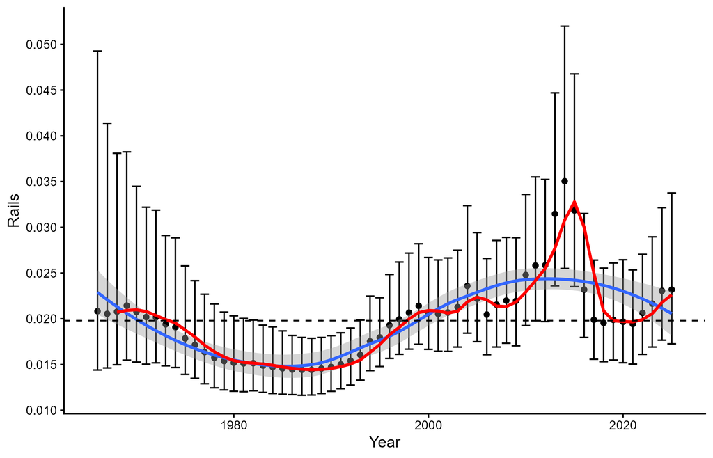

Figure 16: Virginia rail abundance (index) in the United States in spring. Circles are annual estimates of abundance with 95% confidence intervals. The red line is a moving 3-year average and the blue line is a smoothed (Loess model) line with 95% confidence interval (shaded area) fit to the annual estimates. The black dashed reference line is the long term average.

Time series statistics

| Parameter | Estimate | SE | L95%CI | U95%CI |
| --- | --- | --- | --- | --- |
| 1-year index | 0.02 |  | 0.02 | 0.03 |
| 3-year index<sup>a</sup> | 0.02 |  |  |  |
| LTA | 0.02 |  |  |  |
| Objective |  |  |  |  |
| % change from LTA | 17.14 |  |  |  |
| % change from obj |  |  |  |  |
| Mgmt index (n years) | 1.00 |  |  |  |

<sup>a</sup> 2023, 2024, 2025

**Harvest Strategy**  
Management index: Virginia rails per route in spring.

Management thresholds: N/A.

Management prescription: N/A.

Regulatory alternatives:  
Fixed until changed.

### Data Table 11d: Sora

Original data source: North American Breeding Bird Survey; U.S. Geological Survey. Data maintained by U.S. Geological Survey.

Provided in the table below are estimated abundance (Index, birds per route) and lower and upper 95% credible intervals (L95%CI, U95%CI) of sora in spring in the United States (BBS Core area). Also provided is the abundance moving 3-year average (M3yr).

| Year | Index | L95%CI | U95%CI | M3yr |
| --- | --- | --- | --- | --- |
| 1966 | 0.26 | 0.15 | 0.85 | NA |
| 1967 | 0.24 | 0.17 | 0.40 | NA |
| 1968 | 0.31 | 0.21 | 0.50 | 0.27 |
| 1969 | 0.32 | 0.23 | 0.49 | 0.29 |
| 1970 | 0.27 | 0.20 | 0.42 | 0.30 |
| 1971 | 0.32 | 0.23 | 0.48 | 0.30 |
| 1972 | 0.44 | 0.31 | 0.65 | 0.34 |
| 1973 | 0.28 | 0.21 | 0.40 | 0.35 |
| 1974 | 0.30 | 0.22 | 0.44 | 0.34 |
| 1975 | 0.35 | 0.24 | 0.55 | 0.31 |
| 1976 | 0.19 | 0.15 | 0.26 | 0.28 |
| 1977 | 0.18 | 0.14 | 0.25 | 0.24 |
| 1978 | 0.24 | 0.19 | 0.33 | 0.20 |
| 1979 | 0.23 | 0.18 | 0.32 | 0.22 |
| 1980 | 0.24 | 0.18 | 0.32 | 0.24 |
| 1981 | 0.25 | 0.19 | 0.35 | 0.24 |
| 1982 | 0.29 | 0.23 | 0.40 | 0.26 |
| 1983 | 0.29 | 0.22 | 0.39 | 0.28 |
| 1984 | 0.36 | 0.27 | 0.50 | 0.31 |
| 1985 | 0.30 | 0.23 | 0.40 | 0.32 |
| 1986 | 0.29 | 0.22 | 0.38 | 0.31 |
| 1987 | 0.31 | 0.23 | 0.42 | 0.30 |
| 1988 | 0.18 | 0.15 | 0.23 | 0.26 |
| 1989 | 0.16 | 0.14 | 0.20 | 0.22 |
| 1990 | 0.18 | 0.15 | 0.23 | 0.18 |
| 1991 | 0.19 | 0.16 | 0.24 | 0.18 |
| 1992 | 0.21 | 0.17 | 0.27 | 0.19 |
| 1993 | 0.42 | 0.32 | 0.57 | 0.28 |
| 1994 | 0.68 | 0.50 | 0.94 | 0.44 |
| 1995 | 0.88 | 0.65 | 1.20 | 0.66 |
| 1996 | 0.52 | 0.40 | 0.71 | 0.69 |
| 1997 | 0.49 | 0.37 | 0.67 | 0.63 |
| 1998 | 0.41 | 0.32 | 0.56 | 0.48 |
| 1999 | 0.48 | 0.36 | 0.65 | 0.46 |
| 2000 | 0.32 | 0.25 | 0.43 | 0.40 |
| 2001 | 0.28 | 0.22 | 0.37 | 0.36 |
| 2002 | 0.23 | 0.18 | 0.30 | 0.28 |
| 2003 | 0.24 | 0.19 | 0.32 | 0.25 |
| 2004 | 0.26 | 0.20 | 0.34 | 0.24 |
| 2005 | 0.27 | 0.21 | 0.37 | 0.26 |
| 2006 | 0.21 | 0.17 | 0.27 | 0.25 |
| 2007 | 0.41 | 0.31 | 0.55 | 0.30 |
| 2008 | 0.27 | 0.22 | 0.35 | 0.30 |
| 2009 | 0.58 | 0.42 | 0.80 | 0.42 |
| 2010 | 0.61 | 0.46 | 0.83 | 0.49 |
| 2011 | 0.51 | 0.39 | 0.69 | 0.57 |
| 2012 | 0.27 | 0.21 | 0.36 | 0.47 |
| 2013 | 0.49 | 0.36 | 0.67 | 0.42 |
| 2014 | 0.51 | 0.38 | 0.69 | 0.42 |
| 2015 | 0.50 | 0.38 | 0.67 | 0.50 |
| 2016 | 0.26 | 0.21 | 0.33 | 0.42 |
| 2017 | 0.23 | 0.19 | 0.29 | 0.33 |
| 2018 | 0.35 | 0.27 | 0.45 | 0.28 |
| 2019 | 0.83 | 0.63 | 1.11 | 0.47 |
| 2020 | 0.40 | 0.25 | 0.79 | 0.52 |
| 2021 | 0.22 | 0.17 | 0.28 | 0.48 |
| 2022 | 0.48 | 0.36 | 0.66 | 0.37 |
| 2023 | 0.63 | 0.46 | 0.86 | 0.44 |
| 2024 | 0.46 | 0.34 | 0.63 | 0.52 |
| 2025 | 0.34 | 0.25 | 0.45 | 0.47 |

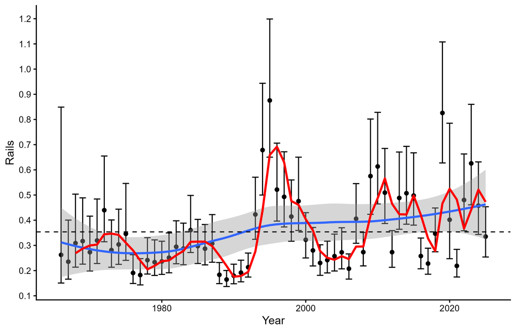

Figure 17: Sora abundance (index) in the United States in spring. Circles are annual estimates of abundance with 95% confidence intervals. The red line is a moving 3-year average and the blue line is a smoothed (Loess model) line with 95% confidence interval (shaded area) fit to the annual estimates. The black dashed reference line is the long term average.

Time series statistics

| Parameter | Estimate | SE | L95%CI | U95%CI |
| --- | --- | --- | --- | --- |
| 1-year index | 0.34 |  | 0.25 | 0.45 |
| 3-year index<sup>a</sup> | 0.47 |  |  |  |
| LTA | 0.35 |  |  |  |
| Objective |  |  |  |  |
| % change from LTA | -5.27 |  |  |  |
| % change from obj |  |  |  |  |
| Mgmt index (n years) | 1.00 |  |  |  |

<sup>a</sup> 2023, 2024, 2025

**Harvest Strategy**  
Management index: Sora per route in spring.

Management thresholds: N/A.

Management prescription: N/A.

Regulatory alternatives:  
Fixed until changed.

### Data Table 11e: Common Gallinule

Original data source: North American Breeding Bird Survey; U.S. Geological Survey. Data maintained by U.S. Geological Survey.

Provided in the table below are estimated abundance (Index, birds per route) and lower and upper 95% credible intervals (L95%CI, U95%CI) of common gallinules in spring in the United States (BBS Core area). Also provided is the abundance moving 3-year average (M3yr).

| Year | Index | L95%CI | U95%CI | M3yr |
| --- | --- | --- | --- | --- |
| 1966 | 0.39 | 0.22 | 0.76 | NA |
| 1967 | 0.38 | 0.22 | 0.70 | NA |
| 1968 | 0.36 | 0.22 | 0.66 | 0.38 |
| 1969 | 0.38 | 0.23 | 0.66 | 0.37 |
| 1970 | 0.41 | 0.25 | 0.71 | 0.38 |
| 1971 | 0.41 | 0.25 | 0.71 | 0.40 |
| 1972 | 0.41 | 0.25 | 0.73 | 0.41 |
| 1973 | 0.42 | 0.25 | 0.73 | 0.41 |
| 1974 | 0.45 | 0.27 | 0.79 | 0.42 |
| 1975 | 0.48 | 0.29 | 0.83 | 0.45 |
| 1976 | 0.45 | 0.28 | 0.79 | 0.46 |
| 1977 | 0.45 | 0.28 | 0.78 | 0.46 |
| 1978 | 0.50 | 0.31 | 0.86 | 0.47 |
| 1979 | 0.61 | 0.38 | 1.03 | 0.52 |
| 1980 | 0.67 | 0.42 | 1.13 | 0.59 |
| 1981 | 0.68 | 0.43 | 1.11 | 0.65 |
| 1982 | 0.69 | 0.44 | 1.11 | 0.68 |
| 1983 | 0.76 | 0.49 | 1.25 | 0.71 |
| 1984 | 0.72 | 0.46 | 1.16 | 0.72 |
| 1985 | 0.65 | 0.42 | 1.02 | 0.71 |
| 1986 | 0.61 | 0.40 | 0.96 | 0.66 |
| 1987 | 0.58 | 0.39 | 0.88 | 0.61 |
| 1988 | 0.54 | 0.36 | 0.81 | 0.57 |
| 1989 | 0.50 | 0.35 | 0.76 | 0.54 |
| 1990 | 0.47 | 0.32 | 0.70 | 0.50 |
| 1991 | 0.48 | 0.33 | 0.74 | 0.48 |
| 1992 | 0.52 | 0.35 | 0.79 | 0.49 |
| 1993 | 0.52 | 0.36 | 0.78 | 0.51 |
| 1994 | 0.51 | 0.35 | 0.76 | 0.51 |
| 1995 | 0.52 | 0.36 | 0.78 | 0.52 |
| 1996 | 0.56 | 0.38 | 0.83 | 0.53 |
| 1997 | 0.52 | 0.36 | 0.78 | 0.54 |
| 1998 | 0.51 | 0.35 | 0.76 | 0.53 |
| 1999 | 0.45 | 0.31 | 0.68 | 0.50 |
| 2000 | 0.39 | 0.26 | 0.58 | 0.45 |
| 2001 | 0.36 | 0.25 | 0.54 | 0.40 |
| 2002 | 0.35 | 0.24 | 0.53 | 0.37 |
| 2003 | 0.40 | 0.27 | 0.59 | 0.37 |
| 2004 | 0.46 | 0.31 | 0.71 | 0.40 |
| 2005 | 0.49 | 0.34 | 0.76 | 0.45 |
| 2006 | 0.45 | 0.31 | 0.68 | 0.47 |
| 2007 | 0.39 | 0.27 | 0.58 | 0.44 |
| 2008 | 0.31 | 0.21 | 0.47 | 0.38 |
| 2009 | 0.28 | 0.18 | 0.42 | 0.32 |
| 2010 | 0.30 | 0.20 | 0.47 | 0.29 |
| 2011 | 0.29 | 0.19 | 0.45 | 0.29 |
| 2012 | 0.29 | 0.19 | 0.46 | 0.29 |
| 2013 | 0.30 | 0.20 | 0.48 | 0.29 |
| 2014 | 0.31 | 0.21 | 0.50 | 0.30 |
| 2015 | 0.34 | 0.22 | 0.54 | 0.32 |
| 2016 | 0.40 | 0.27 | 0.63 | 0.35 |
| 2017 | 0.45 | 0.30 | 0.73 | 0.40 |
| 2018 | 0.43 | 0.29 | 0.70 | 0.43 |
| 2019 | 0.40 | 0.26 | 0.66 | 0.43 |
| 2020 | 0.39 | 0.24 | 0.68 | 0.41 |
| 2021 | 0.38 | 0.24 | 0.69 | 0.39 |
| 2022 | 0.41 | 0.25 | 0.78 | 0.39 |
| 2023 | 0.42 | 0.25 | 0.80 | 0.40 |
| 2024 | 0.45 | 0.27 | 0.88 | 0.42 |
| 2025 | 0.45 | 0.26 | 0.90 | 0.44 |

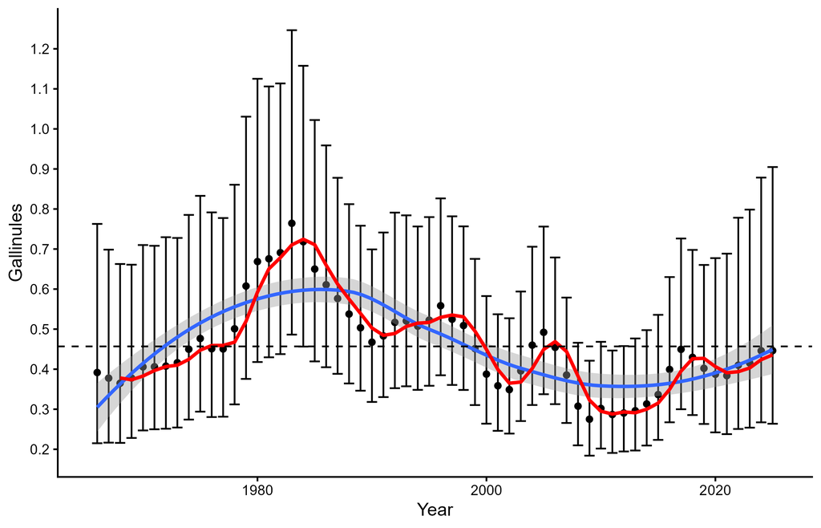

Figure 18: Common gallinule abundance (index) in the United States in spring. Circles are annual estimates of abundance with 95% confidence intervals. The red line is a moving 3-year average and the blue line is a smoothed (Loess model) line with 95% confidence interval (shaded area) fit to the annual estimates. The black dashed reference line is the long term average.

Time series statistics

| Parameter | Estimate | SE | L95%CI | U95%CI |
| --- | --- | --- | --- | --- |
| 1-year index | 0.45 |  | 0.26 | 0.9 |
| 3-year index<sup>a</sup> | 0.44 |  |  |  |
| LTA | 0.46 |  |  |  |
| Objective |  |  |  |  |
| % change from LTA | -2.31 |  |  |  |
| % change from obj |  |  |  |  |
| Mgmt index (n years) | 1.00 |  |  |  |

<sup>a</sup> 2023, 2024, 2025

**Harvest Strategy**  
Management index: Common gallinules per route in spring.

Management thresholds: N/A.

Management prescription: N/A.

Regulatory alternatives:  
Fixed until changed.

## Duck AHM Protocols

### Data Table 30: Midcontinent Mallard

Original data source: Waterfowl Breeding Population and Habitat Survey (WBPHS) and State Breeding Waterfowl Surveys in Michigan, Minnesota, and Wisconsin; USFWS Headquarters, Michigan, Minnesota, and Wisconsin. Data maintained by the USFWS Mississippi Flyway Office.

Provided in the table below are estimated abundance and standard error (SE) of Midcontinent Population mallards (Mcmal) in spring. For purposes of the assessment, Midcontinent Population mallards consist of two segments: Central North America segment (WBPHS) are those breeding in central North America (Federal WBPHS strata 13–18, 20–50, and 75–77) and Great Lakes region segment (GLR) are those breeding in Michigan, Minnesota, and Wisconsin (State surveys). Also provided are the standard errors (SE) associated with the estimates and moving 3-year average (M3yr).

Table 30. Midcontinent Population mallard abundance in spring, 1955-2026.

| Year | WBPHS | WBPHS.SE | GLR | GLR.SE | Mcmal | Mcmal.SE | M3yr | M3yr.SE |
| --- | --- | --- | --- | --- | --- | --- | --- | --- |
| 1955 | 8,604,048 | 452,802 | NA | NA | NA | NA | NA | NA |
| 1956 | 10,278,224 | 457,748 | NA | NA | NA | NA | NA | NA |
| 1957 | 9,136,744 | 442,841 | NA | NA | NA | NA | NA | NA |
| 1958 | 11,048,305 | 554,804 | NA | NA | NA | NA | NA | NA |
| 1959 | 8,810,242 | 466,015 | NA | NA | NA | NA | NA | NA |
| 1960 | 7,212,275 | 353,643 | NA | NA | NA | NA | NA | NA |
| 1961 | 7,044,956 | 509,388 | NA | NA | NA | NA | NA | NA |
| 1962 | 5,364,162 | 426,554 | NA | NA | NA | NA | NA | NA |
| 1963 | 6,539,889 | 325,939 | NA | NA | NA | NA | NA | NA |
| 1964 | 5,957,718 | 385,058 | NA | NA | NA | NA | NA | NA |
| 1965 | 4,942,109 | 273,444 | NA | NA | NA | NA | NA | NA |
| 1966 | 6,603,386 | 310,992 | NA | NA | NA | NA | NA | NA |
| 1967 | 7,252,790 | 336,940 | NA | NA | NA | NA | NA | NA |
| 1968 | 6,848,309 | 339,485 | NA | NA | NA | NA | NA | NA |
| 1969 | 7,368,759 | 279,428 | NA | NA | NA | NA | NA | NA |
| 1970 | 9,691,976 | 616,236 | NA | NA | NA | NA | NA | NA |
| 1971 | 9,249,224 | 458,971 | NA | NA | NA | NA | NA | NA |
| 1972 | 9,003,673 | 362,803 | NA | NA | NA | NA | NA | NA |
| 1973 | 7,833,951 | 376,581 | NA | NA | NA | NA | NA | NA |
| 1974 | 6,601,911 | 350,414 | NA | NA | NA | NA | NA | NA |
| 1975 | 7,594,186 | 343,706 | NA | NA | NA | NA | NA | NA |
| 1976 | 7,752,191 | 336,514 | NA | NA | NA | NA | NA | NA |
| 1977 | 6,937,283 | 377,678 | NA | NA | NA | NA | NA | NA |
| 1978 | 7,106,126 | 304,824 | NA | NA | NA | NA | NA | NA |
| 1979 | 7,607,661 | 325,007 | NA | NA | NA | NA | NA | NA |
| 1980 | 7,307,381 | 304,632 | NA | NA | NA | NA | NA | NA |
| 1981 | 5,933,450 | 304,510 | NA | NA | NA | NA | NA | NA |
| 1982 | 6,153,748 | 300,769 | NA | NA | NA | NA | NA | NA |
| 1983 | 6,134,320 | 285,518 | NA | NA | NA | NA | NA | NA |
| 1984 | 4,911,089 | 253,017 | NA | NA | NA | NA | NA | NA |
| 1985 | 4,741,813 | 233,433 | NA | NA | NA | NA | NA | NA |
| 1986 | 5,890,697 | 240,216 | NA | NA | NA | NA | NA | NA |
| 1987 | 5,603,974 | 217,029 | NA | NA | NA | NA | NA | NA |
| 1988 | 6,012,630 | 308,084 | NA | NA | NA | NA | NA | NA |
| 1989 | 5,233,933 | 241,728 | NA | NA | NA | NA | NA | NA |
| 1990 | 5,085,452 | 235,718 | NA | NA | NA | NA | NA | NA |
| 1991 | 5,059,261 | 202,354 | NA | NA | NA | NA | NA | NA |
| 1992 | 5,630,369 | 237,874 | 996,364 | 96,938 | 6,626,733 | 256,868 | NA | NA |
| 1993 | 5,425,311 | 206,774 | 917,584 | 64,365 | 6,342,895 | 216,560 | NA | NA |
| 1994 | 6,629,191 | 280,314 | 1,130,390 | 99,085 | 7,759,581 | 297,311 | 6,909,736 | 259,019 |
| 1995 | 7,745,215 | 279,303 | 1,085,669 | 100,532 | 8,830,883 | 296,845 | 7,644,453 | 272,891 |
| 1996 | 7,419,309 | 259,289 | 1,007,404 | 84,099 | 8,426,713 | 272,586 | 8,339,059 | 289,145 |
| 1997 | 9,355,448 | 304,126 | 1,077,730 | 94,882 | 10,433,177 | 318,583 | 9,230,258 | 296,600 |
| 1998 | 8,804,148 | 293,985 | 1,078,328 | 95,555 | 9,882,476 | 309,124 | 9,580,789 | 300,753 |
| 1999 | 10,092,628 | 337,443 | 1,030,935 | 102,248 | 11,123,563 | 352,594 | 10,479,739 | 327,300 |
| 2000 | 8,699,879 | 285,470 | 1,199,298 | 97,833 | 9,899,177 | 301,769 | 10,301,739 | 321,944 |
| 2001 | 7,185,669 | 220,365 | 828,216 | 60,483 | 8,013,886 | 228,515 | 9,678,875 | 298,667 |
| 2002 | 6,836,368 | 241,237 | 1,068,375 | 78,213 | 7,904,743 | 253,599 | 8,605,935 | 263,056 |
| 2003 | 7,106,247 | 258,862 | 840,730 | 56,197 | 7,946,977 | 264,892 | 7,955,202 | 249,466 |
| 2004 | 6,614,179 | 274,644 | 946,472 | 79,059 | 7,560,651 | 285,797 | 7,804,124 | 268,427 |
| 2005 | 6,052,128 | 275,437 | 813,825 | 60,280 | 6,865,953 | 281,956 | 7,457,860 | 277,697 |
| 2006 | 6,760,717 | 218,691 | 624,857 | 49,113 | 7,385,574 | 224,138 | 7,270,726 | 265,466 |
| 2007 | 7,725,803 | 280,467 | 790,423 | 61,092 | 8,516,226 | 287,043 | 7,589,251 | 265,914 |
| 2008 | 7,191,395 | 252,487 | 686,499 | 48,663 | 7,877,894 | 257,134 | 7,926,565 | 257,390 |
| 2009 | 8,009,408 | 244,180 | 695,802 | 56,275 | 8,705,210 | 250,581 | 8,366,443 | 265,394 |
| 2010 | 7,824,583 | 279,917 | 780,847 | 58,580 | 8,605,430 | 285,981 | 8,396,178 | 265,012 |
| 2011 | 8,766,766 | 264,970 | 730,635 | 64,171 | 9,497,401 | 272,630 | 8,936,014 | 270,126 |
| 2012 | 10,095,933 | 319,911 | 861,184 | 175,147 | 10,957,116 | 364,719 | 9,686,649 | 310,447 |
| 2013 | 10,033,511 | 358,606 | 763,796 | 74,425 | 10,797,307 | 366,248 | 10,417,275 | 337,384 |
| 2014 | 10,398,943 | 342,857 | 645,863 | 68,144 | 11,044,805 | 349,563 | 10,933,076 | 360,255 |
| 2015 | 11,172,406 | 358,201 | 620,182 | 51,353 | 11,792,587 | 361,863 | 11,211,566 | 359,294 |
| 2016 | 11,208,329 | 361,531 | 692,462 | 70,745 | 11,900,791 | 368,388 | 11,579,394 | 360,023 |
| 2017 | 9,950,010 | 329,813 | 692,694 | 52,318 | 10,642,703 | 333,937 | 11,445,360 | 355,044 |
| 2018 | 8,804,403 | 295,472 | 763,384 | 70,153 | 9,567,787 | 303,686 | 10,703,761 | 336,377 |
| 2019 | 9,062,351 | 282,259 | 669,824 | 67,873 | 9,732,175 | 290,304 | 9,980,888 | 309,847 |
| 2020 | NA | NA | NA | NA | NA | NA | NA | NA |
| 2021 | NA | NA | NA | NA | NA | NA | NA | NA |
| 2022 | 6,819,849 | 233,044 | 555,388 | 46,766 | 7,375,237 | 237,690 | 8,891,733 | 278,687 |
| 2023 | 5,744,806 | 201,781 | 471,567 | 54,739 | 6,216,373 | 209,074 | 7,774,595 | 247,982 |
| 2024 | 6,102,674 | 247,174 | 509,261 | 51,824 | 6,611,935 | 252,548 | 6,734,515 | 233,801 |
| 2025 | 6,164,234 | 258,063 | 400,626 | 46,056 | 6,564,860 | 262,140 | 6,464,389 | 242,356 |
| 2026 | 5,455,275 | 228,668 | 556,774 | 62,126 | 6,012,049 | 236,957 | 6,396,282 | 250,763 |

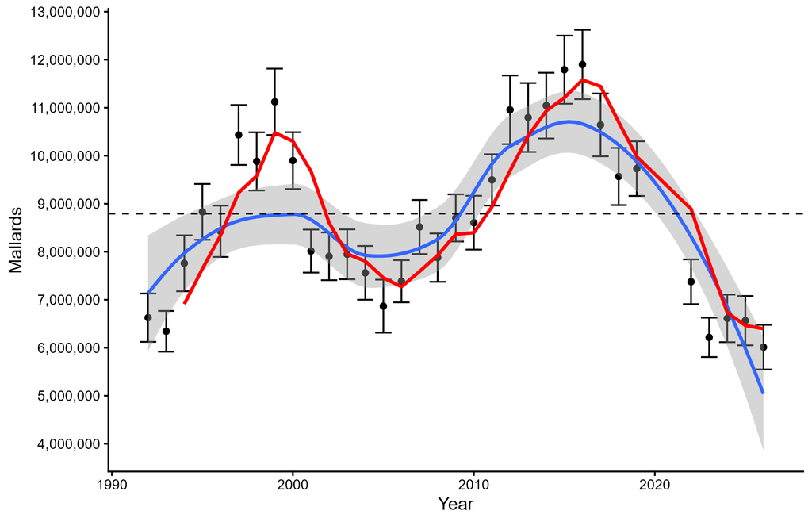

Figure 19: Midcontinent Population mallard abundance in spring. Circles are annual estimates of abundance with 95% confidence intervals. The red line is a moving 3-year average and the blue line is a smoothed (Loess model) line with 95% confidence interval (shaded area) fit to the annual estimates. The black dashed reference line is the long term average.

Time series statistics

| Parameter | Estimate | SE | L95%CI | U95%CI |
| --- | --- | --- | --- | --- |
| 1-year index | 6,012,049 | 236,957 | 5,547,613 | 6,476,485 |
| 3-year index<sup>a</sup> | 6,396,282 | 250,763 | 5,904,785 | 6,887,778 |
| LTA | 8,794,026 |  |  |  |
| Objective |  |  |  |  |
| % change from LTA | -32 |  |  |  |
| % change from obj |  |  |  |  |
| Mgmt index (n years) | 1 |  |  |  |

<sup>a</sup> 2024, 2025, 2026

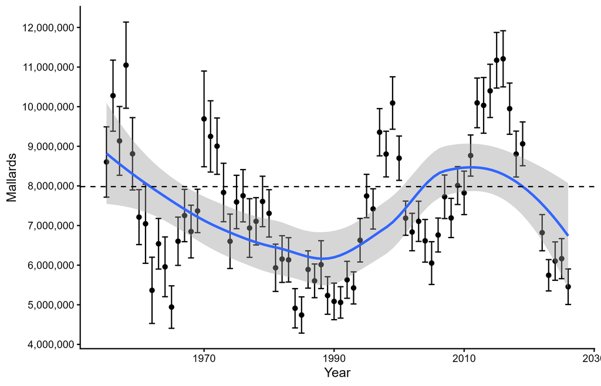

Figure 20: Midcontinent Population mallard Central North America segment abundance in spring. Circles are annual estimates of abundance with 95% confidence intervals. The blue line is a smoothed (Loess model) line with 95% confidence interval (shaded area) fit to the annual estimates. The black dashed reference line is the long term average.

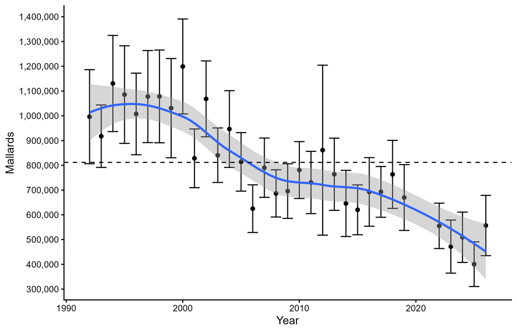

Figure 21: Midcontinent Population mallard Great Lakes Region segment abundance in spring. Circles are annual estimates of abundance with 95% confidence intervals. The blue line is a smoothed (Loess model) line with 95% confidence interval (shaded area) fit to the annual estimates. The black dashed reference line is the long term average.

**Harvest Strategy**  
Management index: Mallards in Central North America and Great Lakes Region population segments in spring.

Management thresholds:  
Liberal  
Moderate  
Restrictive  
Closed  
See the Adaptive Harvest Management (AHM) report for the derived threshold values based on the decision framework for Midcontinent mallards.

Management prescription: See Adaptive Harvest Management (AHM) report for decision based on the AHM protocol for Midcontinent mallards.

Regulatory alternatives:  
Liberal  
60 days, 6-bird daily bag limit, Saturday nearest Sep 24-Jan 31, mallards 4 (2 female)  
Moderate  
45 days, 6-bird daily bag limit, Saturday nearest Sep 24-Jan 31, mallards 4 (1 female)  
Restrictive  
30 days, 3-bird daily bag limit, Saturday nearest Sep 24-Jan 31, mallards 2 (1 female)  
Closed

### Data Table 31: Canvasback

Original data source: Waterfowl Breeding Population and Habitat Survey (WBPHS) Traditional Survey Area; USFWS Headquarters.

Provided in the table below are estimated abundance (Estimate) and standard error (SE) of canvasbacks in spring. Also provided are the abundance moving 3-year average (M3yr) and standard error (M3yr.SE).

Table 31. Canvasback abundance in spring, 1955-2026.

| Year | Estimate | SE | M3yr | M3yr.SE |
| --- | --- | --- | --- | --- |
| 1955 | 589,257 | 87,849 | NA | NA |
| 1956 | 698,509 | 93,324 | NA | NA |
| 1957 | 626,072 | 94,732 | 637,946 | 92,016 |
| 1958 | 746,830 | 96,139 | 690,471 | 94,739 |
| 1959 | 488,684 | 50,588 | 620,529 | 83,219 |
| 1960 | 605,698 | 82,438 | 613,737 | 78,736 |
| 1961 | 435,251 | 65,676 | 509,877 | 67,499 |
| 1962 | 360,238 | 43,836 | 467,062 | 65,906 |
| 1963 | 506,235 | 74,904 | 433,908 | 62,837 |
| 1964 | 643,636 | 126,904 | 503,370 | 88,763 |
| 1965 | 522,120 | 52,816 | 557,330 | 90,378 |
| 1966 | 663,114 | 78,043 | 609,623 | 91,259 |
| 1967 | 502,576 | 45,359 | 562,603 | 60,381 |
| 1968 | 563,691 | 101,260 | 576,460 | 78,319 |
| 1969 | 503,530 | 53,696 | 523,266 | 71,167 |
| 1970 | 580,100 | 90,426 | 549,107 | 84,288 |
| 1971 | 450,674 | 55,188 | 511,435 | 68,571 |
| 1972 | 425,912 | 45,959 | 485,562 | 66,670 |
| 1973 | 620,451 | 89,070 | 499,012 | 66,059 |
| 1974 | 512,842 | 56,820 | 519,735 | 66,519 |
| 1975 | 595,098 | 56,065 | 576,130 | 69,054 |
| 1976 | 614,389 | 70,064 | 574,110 | 61,321 |
| 1977 | 664,042 | 74,860 | 624,510 | 67,469 |
| 1978 | 373,174 | 41,492 | 550,535 | 63,861 |
| 1979 | 582,004 | 59,814 | 539,740 | 60,286 |
| 1980 | 734,570 | 83,764 | 563,249 | 64,072 |
| 1981 | 620,843 | 59,108 | 645,805 | 68,527 |
| 1982 | 513,265 | 50,928 | 622,893 | 66,090 |
| 1983 | 526,612 | 58,865 | 553,573 | 56,429 |
| 1984 | 530,129 | 60,150 | 523,335 | 56,794 |
| 1985 | 375,929 | 42,945 | 477,556 | 54,551 |
| 1986 | 438,350 | 41,537 | 448,136 | 48,947 |
| 1987 | 450,109 | 77,894 | 421,462 | 56,678 |
| 1988 | 435,048 | 40,221 | 441,169 | 56,008 |
| 1989 | 477,439 | 48,410 | 454,198 | 57,818 |
| 1990 | 539,318 | 60,326 | 483,935 | 50,334 |
| 1991 | 491,151 | 66,363 | 502,636 | 58,841 |
| 1992 | 481,529 | 97,303 | 503,999 | 76,401 |
| 1993 | 472,055 | 67,642 | 481,578 | 78,416 |
| 1994 | 525,604 | 71,113 | 493,063 | 79,792 |
| 1995 | 770,593 | 92,161 | 589,417 | 77,731 |
| 1996 | 848,487 | 118,334 | 714,894 | 95,836 |
| 1997 | 688,754 | 57,161 | 769,278 | 92,671 |
| 1998 | 685,862 | 63,795 | 741,034 | 84,341 |
| 1999 | 716,039 | 79,121 | 696,885 | 67,323 |
| 2000 | 706,754 | 80,997 | 702,885 | 75,034 |
| 2001 | 579,826 | 52,652 | 667,539 | 72,094 |
| 2002 | 486,597 | 43,819 | 591,059 | 61,245 |
| 2003 | 557,575 | 47,984 | 541,332 | 48,286 |
| 2004 | 617,227 | 64,553 | 553,800 | 52,882 |
| 2005 | 520,574 | 52,945 | 565,125 | 55,596 |
| 2006 | 691,013 | 69,616 | 609,605 | 62,761 |
| 2007 | 864,924 | 86,197 | 692,170 | 70,898 |
| 2008 | 488,667 | 45,378 | 681,535 | 69,127 |
| 2009 | 662,135 | 57,448 | 671,909 | 65,293 |
| 2010 | 585,164 | 50,828 | 578,655 | 51,455 |
| 2011 | 691,560 | 45,987 | 646,286 | 51,635 |
| 2012 | 759,935 | 68,515 | 678,886 | 55,954 |
| 2013 | 786,978 | 57,583 | 746,158 | 58,095 |
| 2014 | 685,262 | 50,702 | 744,058 | 59,388 |
| 2015 | 757,281 | 63,279 | 743,174 | 57,419 |
| 2016 | 736,472 | 68,750 | 726,338 | 61,377 |
| 2017 | 732,531 | 61,685 | 742,095 | 64,642 |
| 2018 | 686,084 | 59,125 | 718,362 | 63,318 |
| 2019 | 651,925 | 49,085 | 690,180 | 56,892 |
| 2020 | NA | NA | NA | NA |
| 2021 | NA | NA | NA | NA |
| 2022 | 586,643 | 50,570 | 641,551 | 53,111 |
| 2023 | 618,898 | 63,898 | 619,156 | 54,923 |
| 2024 | 566,319 | 52,274 | 590,620 | 55,895 |
| 2025 | 690,238 | 60,000 | 625,152 | 58,922 |
| 2026 | 781,619 | 69,592 | 679,392 | 61,034 |

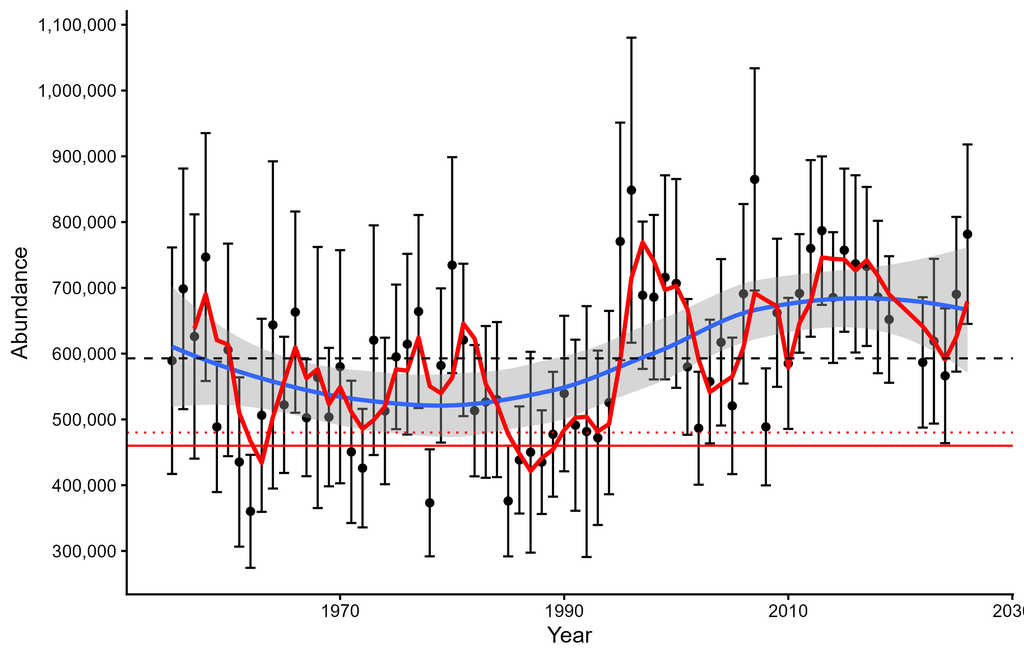

Figure 22: Canvasback abundance in spring. Circles are annual estimates of abundance with 95% confidence intervals. The red line is a moving 3-year average and the blue line is a smoothed (Loess model) line with 95% confidence interval (shaded area) fit to the annual estimates. The black dashed reference line is the long term average. The red dashed reference line is the restriction threshold if abundance is below 480,000 birds (minumum population objective). The red reference line is the closure threshold.

Time series statistics

| Parameter | Estimate | SE | L95%CI | U95%CI |
| --- | --- | --- | --- | --- |
| 1-year index | 781,619 | 69,592 | 645,218 | 918,019 |
| 3-year index<sup>a</sup> | 679,392 | 61,034 | 559,765 | 799,019 |
| LTA | 592,846 |  |  |  |
| Objective | 480,000 |  |  |  |
| % change from LTA | 32 |  |  |  |
| % change from obj | 63 |  |  |  |
| Mgmt index (n years) | 1 |  |  |  |

<sup>a</sup> 2024, 2025, 2026

**Harvest Strategy**  
Management index: Canvasbacks in spring.

Management thresholds:  
≥480,000 Liberal 2  
≥460,000 Liberal 1  
Closed

Management prescription: Liberal 2.

Regulatory alternatives:  
Season length and outside dates based on duck AHM  
Liberal 2  
Daily bag limit 2  
Liberal 1  
Daily bag limit 1  
Closed

Following the adoption of SEIS 2013 (Department of the Interior 2013), a decision support tool for canvasback harvest management was developed. The decision rules under this prescriptive strategy provide that if the canvasback breeding population (BPOP) in year t is 480,000 or above, the year t+1 regulations will be a Liberal 2 (daily bag limit of 2 canvasbacks). If the canvasback BPOP is 460,000 to 479,999, a Liberal 1 (daily bag limit of 1 canvasback), and the season is closed when BPOP is less than 460,000. The prescription is based on point estimates and does not take the variance of BPOP estimates into account.

## Harvest

### Light Goose Conservation Order

A Conservation Order (CO) is a special management action that is needed to control certain wildlife populations when traditional management programs are unsuccessful in preventing overabundance of the population. The Service has authorized a CO in in the Mississippi and Central Flyways under the authority of the Migratory Bird Treaty Act to reduce and stabilize various light goose (snow goose and Ross’s goose) populations (50 CFR 21.180). The CO allows additional methods of taking light geese compared to hunting seasons, allows shooting hours for light geese from one-half hour before sunrise to one-half hour after sunset, and imposes no daily bag limits for light geese inside or outside the migratory bird hunting season. There is no seasonal restriction on control activities (although this mostly occurs in the spring after hunting seasons conclude by March 10); however, control activities may be conducted only when all waterfowl (including light goose) and crane hunting seasons, excluding falconry, are closed.

States and Tribes that participate in the CO must keep annual records of activities carried out under the authority of the conservation order. Specifically, information must be collected on:  
(1) The number of persons participating in the CO (hunters);  
(2) The number of days people participated in the CO (days);  
(3) The number of light geese shot and retrieved under the CO (harvest); and  
(4) The number of light geese shot but not retrieved (crippling).

### Data Table 40a: Light Goose CO Hunters

| Season | AR | IA | IL | IN | KY | LA | MN | MO | MS | TN | CO | KS | MT | ND | NE | NM | OK | SD | TX | WY | MF | CF | Total |
| --- | --- | --- | --- | --- | --- | --- | --- | --- | --- | --- | --- | --- | --- | --- | --- | --- | --- | --- | --- | --- | --- | --- | --- |
| 1999 | 514 | 1,414 | 1,227 | NA | NA | 8,700 | NA | 996 | NA | NA | 1,638 | NA | NA | 6,278 | NA | NA | 597 | 8,630 | 11,170 | NA | 12,851 | 28,313 | 41,164 |
| 2000 | 4,151 | 2,134 | 865 | 23 | 137 | 10,200 | 1,461 | 7,687 | 22 | NA | 3,276 | 2,207 | NA | 5,169 | 3,952 | NA | 494 | 6,067 | 27,882 | NA | 26,680 | 49,047 | 75,727 |
| 2001 | 2,524 | 2,429 | 4,665 | 25 | 148 | 8,600 | 393 | 7,703 | 144 | NA | 2,495 | 1,798 | NA | 1,262 | 4,423 | 603 | 222 | 5,383 | 18,441 | 248 | 26,631 | 34,875 | 61,506 |
| 2002 | 2,867 | 3,095 | 5,107 | 64 | 148 | 7,500 | 1,209 | 8,715 | 183 | NA | 1,323 | 1,939 | NA | 1,494 | 4,775 | 633 | 249 | 8,316 | 21,735 | 191 | 28,888 | 40,655 | 69,543 |
| 2003 | 2,779 | 2,125 | 3,111 | 56 | 159 | 6,000 | 553 | 8,382 | 236 | NA | 2,162 | 1,579 | NA | 2,327 | 7,741 | 383 | 269 | 8,982 | 10,594 | 204 | 23,401 | 34,241 | 57,642 |
| 2004 | 3,114 | 2,584 | 5,976 | 47 | 144 | 5,900 | 690 | 8,316 | 390 | NA | 1,877 | 3,270 | NA | 2,380 | 12,886 | 1,326 | 150 | 6,466 | 7,215 | 221 | 27,161 | 35,791 | 62,952 |
| 2005 | 2,171 | 1,886 | 5,689 | 23 | 98 | 5,000 | 618 | 8,334 | 155 | NA | 1,281 | 1,400 | NA | 2,519 | 8,104 | 426 | 89 | 6,753 | 8,531 | 228 | 23,974 | 29,331 | 53,305 |
| 2006 | 2,616 | 2,457 | 5,543 | 45 | 94 | 5,900 | 516 | 7,735 | 233 | NA | 2,704 | 1,575 | NA | 1,809 | 8,052 | 913 | 106 | 6,914 | 6,665 | 254 | 25,139 | 28,992 | 54,131 |
| 2007 | 2,541 | 2,229 | 5,962 | 106 | 217 | 4,400 | 514 | 7,224 | 320 | NA | 2,367 | 863 | NA | 1,749 | 5,604 | 615 | 112 | 5,288 | 2,585 | 165 | 23,513 | 19,348 | 42,861 |
| 2008 | 2,636 | 2,116 | 6,409 | 160 | 210 | 4,500 | 775 | 7,525 | 343 | NA | 2,555 | 354 | NA | 1,785 | 5,270 | 498 | 122 | 6,601 | 2,473 | 186 | 24,674 | 19,844 | 44,518 |
| 2009 | 2,850 | 1,975 | 4,663 | 134 | 82 | 3,450 | 1,103 | 8,398 | 363 | NA | 1,951 | 931 | NA | 1,319 | 5,609 | 675 | 92 | 6,516 | 2,281 | 177 | 23,018 | 19,551 | 42,569 |
| 2010 | 2,689 | 1,360 | 3,702 | 121 | 106 | 2,600 | 389 | 5,202 | 395 | NA | 1,899 | 1,024 | NA | 1,172 | 4,119 | 97 | 143 | 4,646 | 1,817 | 86 | 16,564 | 15,003 | 31,567 |
| 2011 | 3,092 | 1,582 | 3,825 | 213 | 104 | 2,475 | 455 | 6,309 | 331 | NA | 1,385 | 1,753 | NA | 1,496 | 5,191 | 97 | 149 | 6,120 | 1,676 | 159 | 18,386 | 18,026 | 36,412 |
| 2012 | 3,047 | 1,769 | 5,726 | 210 | 114 | 3,095 | 600 | 6,207 | 230 | NA | 1,847 | 1,944 | NA | 1,965 | 5,629 | 165 | 104 | 4,818 | 1,389 | 163 | 20,998 | 18,024 | 39,022 |
| 2013 | 3,913 | 1,760 | 4,477 | 139 | 198 | 1,850 | 770 | 8,005 | 175 | NA | 2,461 | 2,715 | NA | 2,874 | 4,022 | 120 | 128 | 7,307 | 1,497 | 103 | 21,287 | 21,227 | 42,514 |
| 2014 | 6,001 | 2,096 | 1,962 | 155 | 256 | 580 | 560 | 8,399 | 445 | NA | 3,555 | 3,697 | NA | 2,937 | 3,804 | 205 | 93 | 6,673 | 1,600 | 112 | 20,454 | 22,676 | 43,130 |
| 2015 | 6,744 | 1,877 | 2,599 | 168 | 133 | 982 | 621 | 7,849 | 394 | NA | 2,693 | 3,584 | NA | 3,622 | 5,597 | 256 | 80 | 6,424 | 2,260 | 90 | 21,367 | 24,606 | 45,973 |
| 2016 | 7,019 | 1,724 | 2,187 | 171 | 224 | 1,641 | 534 | 6,440 | 215 | 51 | 2,933 | 2,475 | NA | 3,670 | 4,312 | 59 | 16 | 5,709 | 1,741 | 123 | 20,206 | 21,038 | 41,244 |
| 2017 | 5,889 | 2,488 | 2,459 | 111 | 112 | 938 | 471 | 6,554 | 175 | 17 | 2,921 | 2,430 | NA | 3,357 | 6,167 | 53 | 34 | 7,120 | 1,101 | 135 | 19,214 | 23,318 | 42,532 |
| 2018 | 11,570 | 3,523 | 2,505 | 271 | 109 | 1,265 | 321 | 7,141 | 221 | 45 | 2,821 | 3,232 | NA | 2,245 | 6,052 | 66 | 24 | 7,379 | 1,792 | 169 | 26,971 | 23,780 | 50,751 |
| 2019 | 15,595 | 1,629 | 2,694 | 362 | 131 | 620 | 444 | 5,940 | 195 | 6 | 2,506 | 3,119 | NA | 2,078 | 3,042 | 45 | 21 | 4,113 | 1,531 | 65 | 27,616 | 16,520 | 44,136 |
| 2020 | 17,882 | 1,697 | 3,272 | 169 | 77 | NA | 430 | 6,503 | 202 | 2 | 2,075 | 3,112 | NA | 3,881 | 5,045 | 88 | 20 | 4,908 | 1,039 | 140 | 30,234 | 20,308 | 50,542 |
| 2021 | 12,150 | 964 | 2,702 | 274 | 340 | 3,400 | 375 | 6,944 | 1,053 | 32 | 2,833 | 3,852 | NA | 3,217 | 3,509 | 207 | 66 | 6,201 | 1,257 | 134 | 28,234 | 21,276 | 49,510 |
| 2022 | 14,029 | 1,676 | 1,401 | 190 | 206 | 4,400 | 326 | 4,117 | 730 | 8 | 2,787 | 3,910 | 57 | 2,608 | 4,109 | 1,100 | 111 | 6,430 | 1,288 | 124 | 27,083 | 22,524 | 49,607 |
| 2023 | 13,407 | 1,850 | 2,226 | 215 | 173 | 6,300 | 411 | 7,801 | 400 | 11 | 1,966 | 3,924 | 29 | 2,121 | 4,655 | 130 | 99 | 7,225 | 1,436 | 124 | 32,794 | 21,709 | 54,503 |
| 2024 | 12,688 | 1,821 | 2,529 | 225 | 228 | 3,300 | 270 | 7,261 | 171 | 33 | 1,716 | 3,533 | 34 | 3,111 | 4,741 | 189 | 92 | 7,902 | 1,582 | 142 | 28,526 | 23,042 | 51,568 |
| 2025 | 12,241 | 1,747 | 3,123 | 397 | 279 | 4,100 | 419 | 8,092 | 422 | 26 | 1,754 | 3,984 | 53 | 3,416 | 4,739 | 79 | 193 | 6,950 | NA | 159 | 30,846 | 21,327 | 52,173 |
| 2026 | 13,782 | 1,960 | 3,251 | 294 | 290 | 3,800 | 326 | 8,403 | 383 | 77 | 1,626 | 3,851 | 86 | 2,786 | 4,188 | 38 | 49 | 6,240 | NA | 117 | 32,566 | 18,981 | 51,547 |

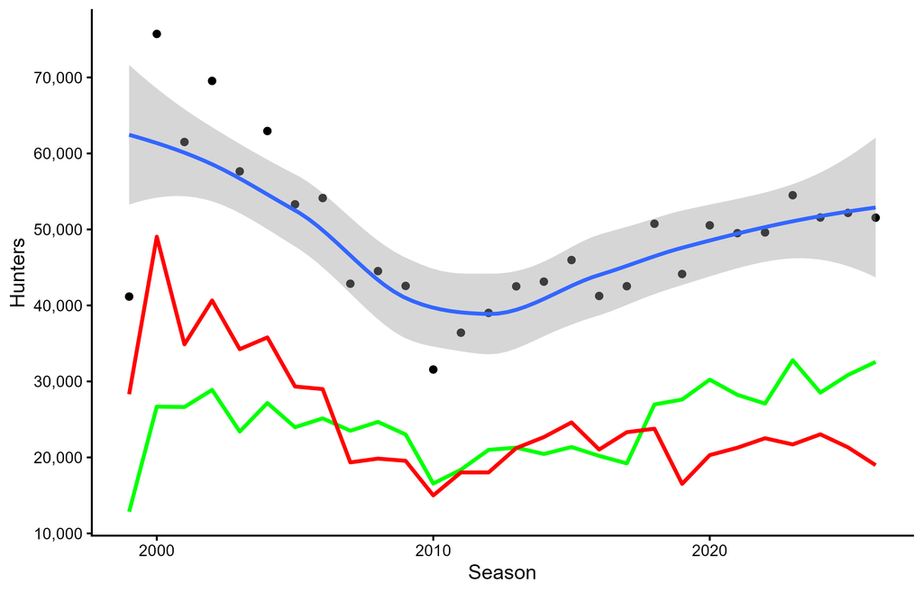

Figure 23: Light goose Conservation Order hunters in the Mississippi and Central Flyways. The blue line is a smoothed (Loess model) line with 95% confidence interval (shaded area) fit to the annual total estimates. The red line is the Central Flyway total. The green line is the Mississippi Flyway total.

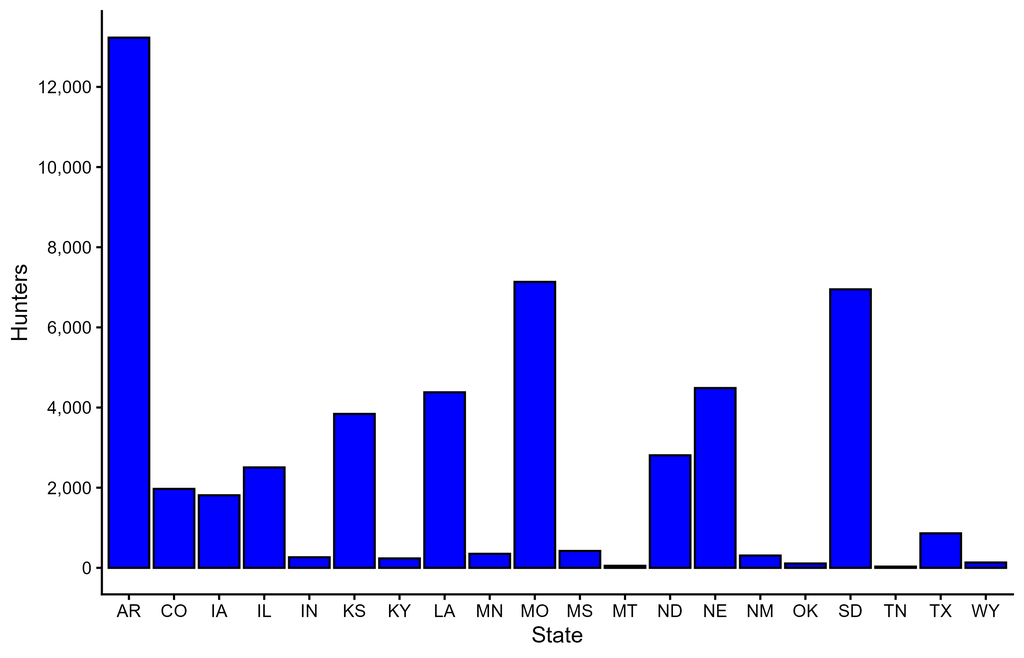

Figure 24: Light goose Conservation Order hunters during the recent 5-year period (average annual) by State in the Mississippi and Central Flyways.

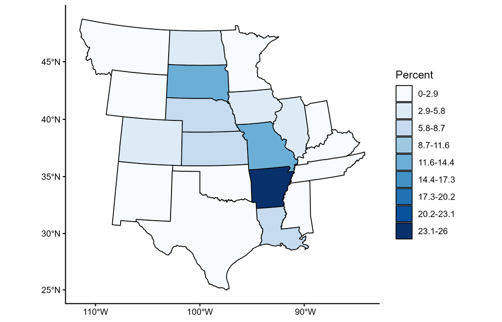

Figure 25: Light goose Conservation Order hunters during the recent 5-year period (average annual) by State in the Mississippi and Central Flyways. Values are proportion of total hunters.

### Data Table 40b: Light Goose CO Days

| Season | AR | IA | IL | IN | KY | LA | MN | MO | MS | TN | CO | KS | MT | ND | NE | NM | OK | SD | TX | WY | MF | CF | Total |
| --- | --- | --- | --- | --- | --- | --- | --- | --- | --- | --- | --- | --- | --- | --- | --- | --- | --- | --- | --- | --- | --- | --- | --- |
| 1999 | 3,033 | 7,366 | 2,504 | NA | NA | 27,900 | NA | 4,889 | NA | NA | 6,709 | NA | NA | 17,578 | NA | NA | 2,651 | 45,165 | NA | NA | 45,692 | 72,103 | 117,795 |
| 2000 | 29,491 | 12,298 | 6,643 | 91 | 435 | 38,900 | 8,244 | 37,946 | 170 | NA | 15,316 | 9,528 | NA | 10,338 | 21,853 | NA | 2,223 | 28,738 | NA | NA | 134,218 | 87,996 | 222,214 |
| 2001 | 18,726 | 14,550 | 32,634 | 119 | 710 | 53,800 | 2,112 | 40,635 | 450 | NA | 8,836 | 7,354 | NA | 3,661 | 12,792 | 1,378 | 1,199 | 22,120 | NA | 993 | 163,736 | 58,333 | 222,069 |
| 2002 | 24,566 | 19,606 | 31,204 | 153 | 532 | 65,200 | 5,517 | 48,831 | 653 | NA | 5,016 | 10,704 | NA | 4,034 | 22,050 | 5,634 | 1,245 | 35,852 | 62,105 | 781 | 196,262 | 147,421 | 343,683 |
| 2003 | 20,144 | 12,508 | 27,177 | 146 | 439 | 62,500 | 2,600 | 42,994 | 1,248 | NA | 10,193 | 8,100 | NA | 6,748 | 26,780 | 1,945 | 1,130 | 31,036 | 22,640 | 794 | 169,756 | 109,366 | 279,122 |
| 2004 | 17,889 | 15,590 | 44,306 | 79 | 583 | 37,400 | 3,372 | 40,232 | 2,054 | NA | 8,547 | 15,548 | NA | 6,721 | 50,574 | NA | 765 | 30,826 | 19,550 | 676 | 161,505 | 133,207 | 294,712 |
| 2005 | 11,983 | 12,402 | 42,349 | 111 | 371 | 37,500 | 2,643 | 43,480 | 855 | NA | 6,593 | 8,679 | NA | 7,557 | 44,057 | 2,932 | 356 | 37,588 | 21,263 | 787 | 151,694 | 129,812 | 281,506 |
| 2006 | 17,473 | 15,580 | 53,154 | 251 | 408 | 36,800 | 2,665 | 35,843 | 1,279 | NA | 12,568 | 7,136 | NA | 6,151 | 44,681 | 8,851 | 530 | 35,029 | 17,865 | 966 | 163,453 | 133,777 | 297,230 |
| 2007 | 16,471 | 12,230 | 39,170 | 352 | 1,017 | 29,300 | 2,302 | 35,175 | 1,630 | NA | 10,847 | 2,509 | NA | 5,947 | 32,637 | 4,646 | 493 | 23,293 | 8,201 | 572 | 137,647 | 89,145 | 226,792 |
| 2008 | 21,263 | 10,706 | 50,471 | 333 | 849 | 22,700 | 3,415 | 34,829 | 1,543 | NA | 11,886 | 1,193 | NA | 6,390 | 28,266 | 3,729 | 451 | 31,331 | 8,032 | 675 | 146,109 | 91,953 | 238,062 |
| 2009 | 17,183 | 14,348 | 33,947 | 564 | 121 | 27,300 | 4,647 | 42,694 | 1,444 | NA | 8,744 | 3,613 | NA | 4,128 | 33,566 | 5,742 | 331 | 30,236 | 6,333 | 609 | 142,248 | 93,302 | 235,550 |
| 2010 | 15,691 | 7,877 | 25,581 | 217 | 301 | 13,800 | 1,475 | 20,937 | 1,206 | NA | 8,829 | 6,367 | NA | 4,008 | 17,302 | NA | 744 | 18,369 | 5,660 | 285 | 87,085 | 61,564 | 148,649 |
| 2011 | 18,790 | 9,013 | 30,753 | 572 | 385 | 21,720 | 1,830 | 26,518 | 1,525 | NA | 10,905 | 9,098 | NA | 4,608 | 26,303 | 349 | 581 | 42,366 | 5,645 | 520 | 111,106 | 100,375 | 211,481 |
| 2012 | 15,143 | 10,050 | 51,763 | 837 | 316 | 44,916 | 2,270 | 29,007 | 1,421 | NA | 8,659 | 11,273 | NA | 6,876 | 32,590 | 302 | 416 | 30,423 | 4,162 | 575 | 155,723 | 95,276 | 250,999 |
| 2013 | 17,172 | 10,382 | 45,724 | 477 | 611 | 23,721 | 3,070 | 38,179 | 795 | NA | 7,533 | 13,654 | NA | 8,824 | 18,620 | 326 | 563 | 31,358 | 5,533 | 346 | 140,131 | 86,756 | 226,887 |
| 2014 | 40,819 | 12,365 | 21,170 | 347 | 639 | 10,450 | 2,580 | 36,820 | 1,021 | NA | 25,311 | 16,748 | NA | 9,985 | 21,913 | 581 | 512 | 29,781 | 4,520 | 339 | 126,211 | 109,690 | 235,901 |
| 2015 | 37,127 | 10,356 | 30,360 | 396 | 1,155 | 23,954 | 2,434 | 36,715 | 1,091 | NA | 13,907 | 13,659 | NA | 12,676 | 25,495 | 529 | 344 | 28,971 | 5,931 | 352 | 143,588 | 101,864 | 245,452 |
| 2016 | 38,102 | 12,969 | 33,048 | 345 | 547 | 15,761 | 2,605 | 31,355 | 759 | 255 | 16,903 | 7,777 | NA | 13,948 | 24,064 | 80 | 77 | 24,561 | 4,391 | 514 | 135,746 | 92,315 | 228,061 |
| 2017 | 31,359 | 17,832 | 32,931 | 488 | 308 | 6,212 | 1,966 | 32,675 | 1,190 | 97 | 15,637 | 9,765 | NA | 10,716 | 36,024 | 80 | 129 | 33,627 | 3,167 | 438 | 125,058 | 109,583 | 234,641 |
| 2018 | 52,700 | 21,898 | 30,989 | 833 | 392 | 17,145 | 1,204 | 32,172 | 1,198 | 192 | 18,076 | 12,158 | NA | 7,067 | 31,801 | 79 | 103 | 32,577 | 4,633 | 527 | 158,723 | 107,021 | 265,744 |
| 2019 | 80,424 | 6,189 | 30,206 | 760 | 353 | 3,847 | 1,537 | 23,976 | 1,057 | 29 | 14,336 | 13,872 | NA | 6,504 | 15,459 | 125 | 57 | 16,466 | 4,569 | 189 | 148,378 | 71,577 | 219,955 |
| 2020 | 89,408 | 8,923 | 41,621 | 362 | 362 | NA | 1,529 | 28,596 | 1,095 | 6 | 11,154 | 15,981 | NA | 14,398 | 25,021 | 103 | 62 | 22,695 | 2,787 | 407 | 171,902 | 92,608 | 264,510 |
| 2021 | 58,441 | 5,568 | 32,369 | 632 | 1,546 | 15,400 | 1,481 | 32,730 | 5,432 | 133 | 14,220 | 15,861 | NA | 12,869 | 17,720 | 207 | 210 | 27,014 | 3,215 | 471 | 153,732 | 91,787 | 245,519 |
| 2022 | 72,529 | 10,877 | 19,254 | 320 | 677 | 24,800 | 1,222 | 26,405 | 3,957 | 88 | 15,997 | 14,914 | 230 | 9,912 | 22,345 | 2,350 | 354 | 28,466 | 3,327 | 712 | 160,129 | 98,607 | 258,736 |
| 2023 | 59,796 | 13,602 | 30,448 | 896 | 694 | 33,000 | 1,675 | 31,870 | 2,166 | 88 | 11,164 | 16,237 | 131 | 6,464 | 25,530 | 282 | 439 | 28,353 | 3,600 | 423 | 174,235 | 92,623 | 266,858 |
| 2024 | 58,110 | 14,389 | 31,139 | 450 | 1,473 | 24,400 | 1,203 | 40,593 | 1,026 | 194 | 10,488 | 16,090 | 79 | 11,199 | 31,838 | 756 | 345 | 42,717 | 4,169 | 726 | 172,977 | 118,407 | 291,384 |
| 2025 | 50,924 | 16,612 | 33,024 | 1,418 | 1,473 | 7,700 | 2,174 | 49,363 | 2,488 | 103 | 11,342 | 18,970 | 156 | 14,006 | 29,834 | 210 | 599 | 31,139 | NA | 530 | 165,279 | 106,786 | 272,065 |
| 2026 | 64,638 | 11,877 | 34,368 | 988 | 908 | 25,000 | 1,654 | 50,951 | 2,261 | 340 | 12,277 | 19,487 | 262 | 11,423 | 26,705 | 58 | 147 | 28,704 | NA | 466 | 192,985 | 99,529 | 292,514 |

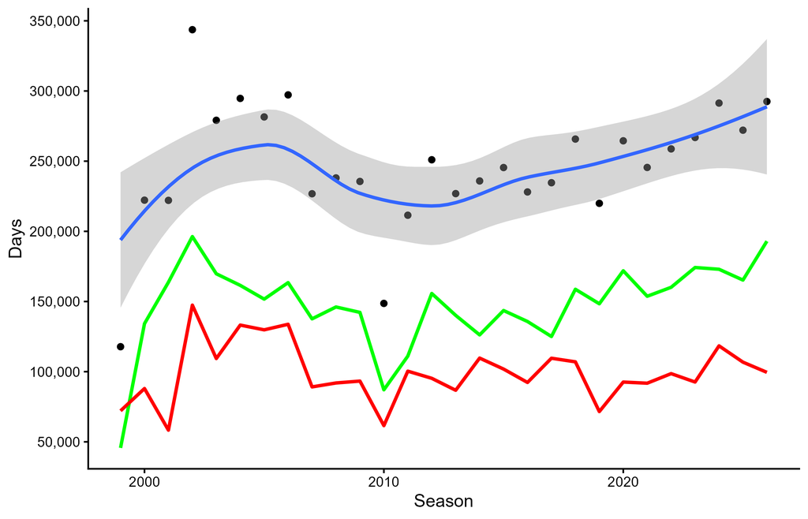

Figure 26: Light goose Conservation Order days in the Mississippi and Central Flyways. The blue line is a smoothed (Loess model) line with 95% confidence interval (shaded area) fit to the annual total estimates. The red line is the Central Flyway total. The green line is the Mississippi Flyway total.

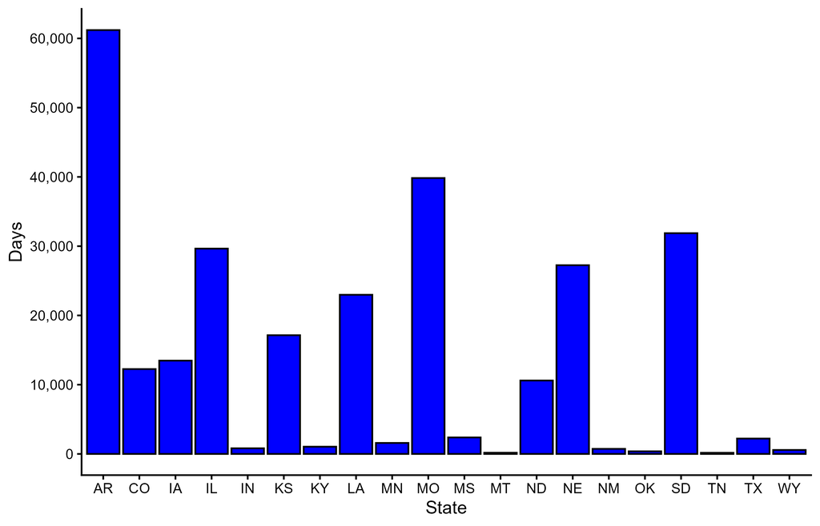

Figure 27: Light goose Conservation Order days during the recent 5-year period (average annual) by State in the Mississippi and Central Flyways.

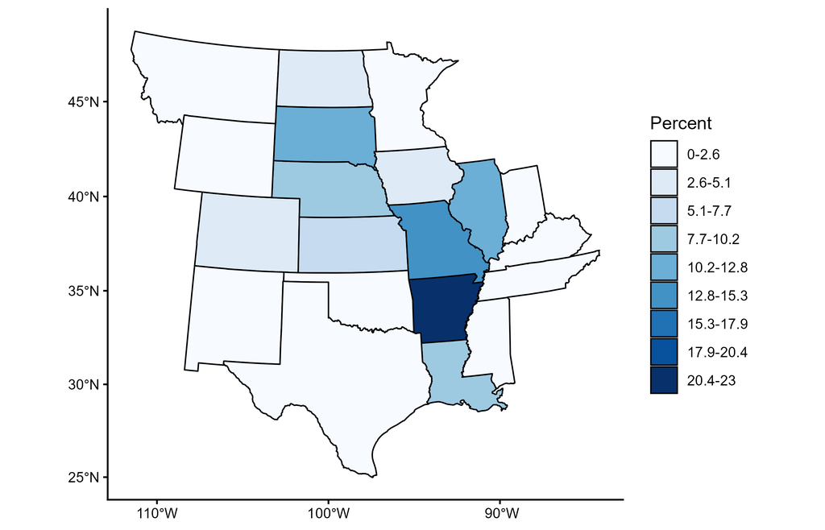

### Data Table 40c: Light Goose CO Harvest

| Season | AR | IA | IL | IN | KY | LA | MN | MO | MS | TN | CO | KS | MT | ND | NE | NM | OK | SD | TX | WY | MF | CF | Total |
| --- | --- | --- | --- | --- | --- | --- | --- | --- | --- | --- | --- | --- | --- | --- | --- | --- | --- | --- | --- | --- | --- | --- | --- |
| 1999 | 17,168 | 12,043 | 2,504 | NA | NA | 155,900 | NA | 17,319 | NA | NA | 13,417 | NA | NA | 34,180 | NA | NA | 6,650 | 95,113 | 53,451 | NA | 204,934 | 202,811 | 407,745 |
| 2000 | 132,156 | 20,681 | 7,612 | 27 | 952 | 110,300 | 6,290 | 84,521 | 333 | NA | 31,783 | 11,165 | NA | 48,601 | 27,834 | 174 | 2,668 | 68,917 | 102,225 | NA | 362,872 | 293,367 | 656,239 |
| 2001 | 75,807 | 13,851 | 36,830 | 45 | 1,170 | 101,700 | 316 | 94,354 | 379 | NA | 22,457 | 11,937 | NA | 4,935 | 16,315 | 1,925 | 1,603 | 54,375 | 77,322 | 875 | 324,452 | 191,744 | 516,196 |
| 2002 | 135,327 | 29,249 | 17,875 | 168 | 1,235 | 102,800 | 3,516 | 168,196 | 1,554 | NA | 7,594 | 35,138 | NA | 10,558 | 54,300 | 2,253 | 3,548 | 91,162 | 87,794 | 1,216 | 459,920 | 293,563 | 753,483 |
| 2003 | 91,505 | 17,006 | 30,564 | 17 | 1,288 | 98,600 | 2,005 | 140,806 | 3,600 | NA | 27,395 | 17,087 | NA | 20,256 | 87,585 | 1,268 | 1,991 | 70,072 | 35,625 | 1,772 | 385,391 | 263,051 | 648,442 |
| 2004 | 88,606 | 32,181 | 37,189 | 41 | 1,168 | 105,500 | 2,735 | 147,262 | 7,955 | NA | 24,497 | 65,608 | NA | 21,085 | 138,012 | 7,372 | 1,575 | 96,767 | 34,827 | 1,364 | 422,637 | 391,107 | 813,744 |
| 2005 | 77,228 | 12,771 | 43,839 | 42 | 450 | 66,800 | 1,395 | 134,814 | 3,223 | NA | 16,135 | 25,272 | NA | 29,384 | 111,172 | 736 | 490 | 116,397 | 37,354 | 1,070 | 340,562 | 338,010 | 678,572 |
| 2006 | 137,908 | 21,263 | 74,268 | 277 | 731 | 96,300 | 1,360 | 142,639 | 6,108 | NA | 18,535 | 18,802 | NA | 24,870 | 129,631 | 2,529 | 615 | 99,547 | 28,905 | 2,622 | 480,854 | 326,056 | 806,910 |
| 2007 | 116,818 | 17,525 | 44,514 | 1,216 | 3,657 | 80,500 | 1,786 | 159,020 | 11,776 | NA | 23,375 | 12,711 | NA | 42,870 | 96,724 | 2,765 | 1,198 | 96,555 | 17,817 | 928 | 436,812 | 294,943 | 731,755 |
| 2008 | 122,881 | 15,198 | 97,021 | 155 | 2,547 | 58,900 | 2,412 | 141,779 | 8,965 | NA | 13,745 | 4,260 | NA | 33,006 | 65,947 | 2,145 | 842 | 107,137 | 22,831 | 1,019 | 449,858 | 250,932 | 700,790 |
| 2009 | 137,127 | 23,652 | 85,635 | 78 | 652 | 49,600 | 4,366 | 224,313 | 10,924 | NA | 23,072 | 11,924 | NA | 23,070 | 135,247 | 2,480 | 561 | 116,949 | 14,217 | 845 | 536,347 | 328,365 | 864,712 |
| 2010 | 115,401 | 8,153 | 65,987 | 45 | 2,378 | 29,000 | 559 | 86,462 | 8,959 | NA | 11,473 | 15,244 | NA | 22,733 | 58,592 | 198 | 930 | 52,548 | 9,409 | 230 | 316,944 | 171,357 | 488,301 |
| 2011 | 149,578 | 15,139 | 66,406 | 264 | 2,571 | 41,686 | 1,554 | 193,461 | 12,618 | NA | 28,193 | 53,863 | NA | 29,379 | 156,891 | 93 | 1,639 | 111,355 | 13,859 | 873 | 483,277 | 396,145 | 879,422 |
| 2012 | 123,161 | 14,946 | 87,558 | 308 | 1,267 | 135,219 | 2,620 | 186,982 | 6,208 | NA | 18,971 | 62,092 | NA | 40,534 | 121,784 | 477 | 520 | 108,358 | 9,924 | 660 | 558,269 | 363,320 | 921,589 |
| 2013 | 158,174 | 22,938 | 73,495 | 974 | 1,586 | 43,637 | 2,430 | 223,267 | 5,632 | NA | 13,417 | 72,447 | NA | 58,820 | 107,283 | 256 | 832 | 168,496 | 12,900 | 436 | 532,133 | 434,887 | 967,020 |
| 2014 | 264,233 | 27,420 | 82,161 | 423 | 2,293 | 26,570 | 2,880 | 248,896 | 6,028 | NA | 34,216 | 95,772 | NA | 48,967 | 86,175 | 803 | 1,581 | 149,115 | 13,436 | 449 | 660,904 | 430,514 | 1,091,418 |
| 2015 | 322,339 | 19,518 | 123,944 | 1,187 | 3,743 | 70,642 | 3,266 | 265,584 | 4,283 | NA | 15,719 | 55,271 | NA | 77,462 | 106,226 | 205 | 648 | 165,331 | 17,516 | 561 | 814,506 | 438,939 | 1,253,445 |
| 2016 | 250,927 | 19,087 | 121,689 | 860 | 1,523 | 12,477 | 2,121 | 178,134 | 3,288 | 1,035 | 23,499 | 41,416 | NA | 68,399 | 96,450 | 16 | 126 | 126,199 | 14,681 | 671 | 591,141 | 371,457 | 962,598 |
| 2017 | 232,087 | 33,306 | 133,629 | 464 | 533 | 5,655 | 1,713 | 171,715 | 5,723 | 371 | 16,102 | 45,501 | NA | 69,276 | 127,897 | 44 | 160 | 181,460 | 7,849 | 1,066 | 585,196 | 449,355 | 1,034,551 |
| 2018 | 669,964 | 56,830 | 103,322 | 1,642 | 1,617 | 38,618 | 1,021 | 273,563 | 5,911 | 2,953 | 56,647 | 73,295 | NA | 75,118 | 129,536 | 934 | 70 | 166,079 | 13,573 | 1,023 | 1,155,441 | 516,275 | 1,671,716 |
| 2019 | 268,057 | 7,606 | 86,683 | 1,050 | 594 | 5,628 | 1,612 | 96,188 | 5,215 | 5 | 20,719 | 78,285 | NA | 31,105 | 30,358 | 136 | 189 | 80,694 | 8,696 | 149 | 472,638 | 250,331 | 722,969 |
| 2020 | 638,372 | 16,600 | 138,954 | 220 | 513 | NA | 785 | 174,625 | 5,402 | 16 | 16,813 | 68,235 | NA | 60,674 | 103,490 | 88 | 145 | 96,846 | 6,634 | 805 | 975,487 | 353,730 | 1,329,217 |
| 2021 | 256,365 | 8,984 | 90,392 | 1,576 | 6,124 | 23,300 | 1,455 | 179,560 | 21,060 | 687 | 15,164 | 81,671 | NA | 67,835 | 64,377 | 310 | 585 | 128,329 | 8,775 | 805 | 589,503 | 367,851 | 957,354 |
| 2022 | 454,536 | 20,849 | 61,777 | 548 | 3,254 | 3,460 | 967 | 160,637 | 19,522 | 104 | 23,266 | 56,674 | 273 | 72,065 | 91,647 | 6,400 | 248 | 169,647 | 7,810 | 2,445 | 725,654 | 430,475 | 1,156,129 |
| 2023 | 525,561 | 18,408 | 113,429 | 1,672 | 2,062 | 46,900 | 1,600 | 309,127 | 10,685 | 355 | 24,118 | 68,592 | 37 | 37,602 | 144,680 | 890 | 813 | 164,571 | 12,182 | 1,345 | 1,029,799 | 454,830 | 1,484,629 |
| 2024 | 693,006 | 27,438 | 71,143 | 1,386 | 4,805 | 51,500 | 699 | 220,852 | 4,788 | 509 | 20,732 | 58,803 | 149 | 92,228 | 169,034 | 189 | 539 | 228,545 | 18,124 | 1,604 | 1,076,126 | 589,947 | 1,666,073 |
| 2025 | 325,864 | 39,215 | 77,295 | 3,938 | 4,381 | 17,700 | 2,887 | 290,287 | 8,862 | 399 | 23,872 | 106,005 | 477 | 108,137 | 147,305 | 158 | 2,339 | 145,381 | NA | 968 | 770,828 | 534,642 | 1,305,470 |
| 2026 | 624,049 | 26,884 | 108,213 | 4,230 | 3,464 | 43,400 | 1,972 | 254,576 | 7,277 | 636 | 13,900 | 75,307 | 118 | 58,843 | 92,088 | 19 | 342 | 155,596 | NA | 505 | 1,074,701 | 396,718 | 1,471,419 |

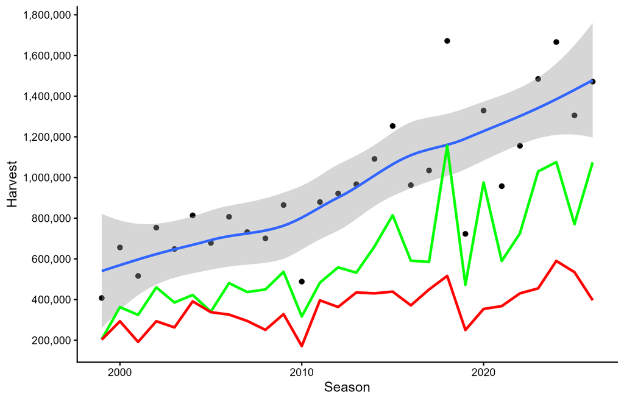

Figure 29: Light goose Conservation Order harvest in the Mississippi and Central Flyways. The blue line is a smoothed (Loess model) line with 95% confidence interval (shaded area) fit to the annual total estimates. The red line is the Central Flyway total. The green line is the Mississippi Flyway total.

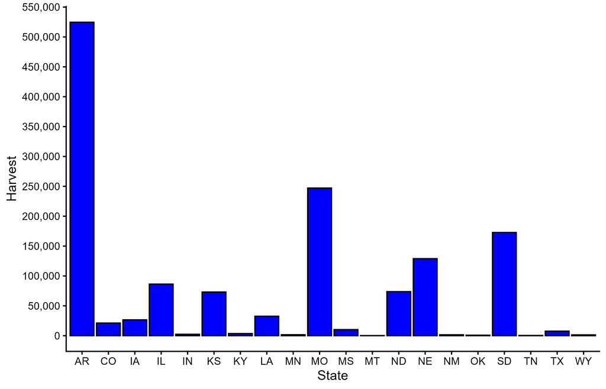

Figure 30: Light goose Conservation Order harvest during the recent 5-year period (average annual) by State in the Mississippi and Central Flyways.

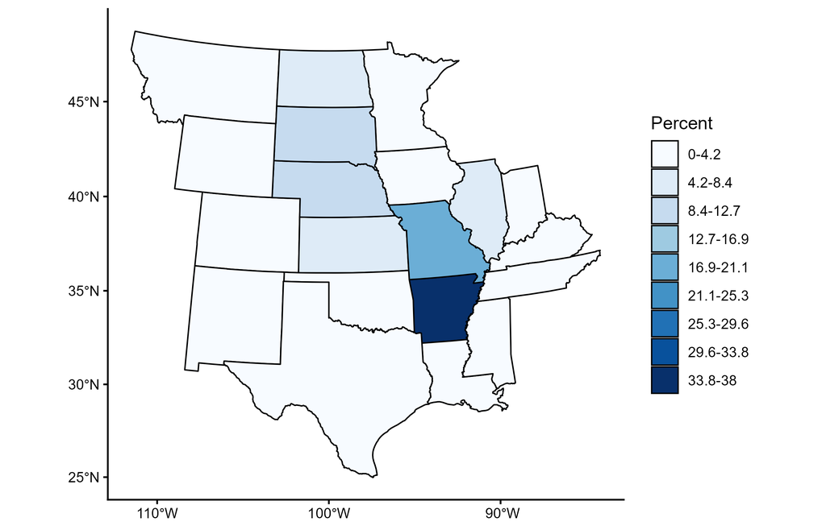